# Nitrogen isotopes and land-use sources of coastal nitrate

## 3.1 Recovering fractions

```r
id_met |>
  filter(regime == "moderate", !truth_enrich, !fit_enrich_aware) |>
  select(structure, overlap, analytical_sd = sigma_a, source, bias, rmse, coverage95, ci_width, r2) |>
  knitr::kable(digits = 2, caption = paste0("Fraction recovery, moderate mixtures, no enrichment, model without enrichment. ",
    "bias = mean(estimate - truth); coverage95 = share of true fractions inside the 95% interval; ci_width = mean interval width; r2 = share of true-fraction variance explained by the posterior mean."))
```

Fraction recovery, moderate mixtures, no enrichment, model without enrichment. bias = mean(estimate - truth); coverage95 = share of true fractions inside the 95% interval; ci_width = mean interval width; r2 = share of true-fraction variance explained by the posterior mean.

| structure | overlap | analytical_sd | source | bias | rmse | coverage95 | ci_width | r2 |
| --- | --- | --- | --- | --- | --- | --- | --- | --- |
| two_source | low | 0.3 | wastewater | 0.08 | 0.19 | 0.96 | 0.82 | 0.33 |
| two_source | low | 0.3 | other | -0.08 | 0.19 | 0.96 | 0.82 | 0.33 |
| two_source | low | 1.0 | wastewater | 0.08 | 0.20 | 0.96 | 0.82 | 0.33 |
| two_source | low | 1.0 | other | -0.08 | 0.20 | 0.96 | 0.82 | 0.33 |
| two_source | high | 0.3 | wastewater | 0.09 | 0.21 | 0.95 | 0.87 | 0.18 |
| two_source | high | 0.3 | other | -0.09 | 0.21 | 0.95 | 0.87 | 0.18 |
| two_source | high | 1.0 | wastewater | 0.11 | 0.22 | 0.95 | 0.87 | 0.11 |
| two_source | high | 1.0 | other | -0.11 | 0.22 | 0.95 | 0.87 | 0.11 |
| three_source | low | 0.3 | wastewater | -0.01 | 0.16 | 0.95 | 0.62 | 0.53 |
| three_source | low | 0.3 | agriculture | 0.00 | 0.20 | 0.95 | 0.71 | 0.24 |
| three_source | low | 0.3 | background | 0.00 | 0.22 | 0.96 | 0.78 | 0.08 |
| three_source | low | 1.0 | wastewater | 0.00 | 0.17 | 0.94 | 0.63 | 0.51 |
| three_source | low | 1.0 | agriculture | 0.00 | 0.21 | 0.95 | 0.71 | 0.24 |
| three_source | low | 1.0 | background | 0.00 | 0.22 | 0.95 | 0.78 | 0.08 |
| three_source | high | 0.3 | wastewater | 0.00 | 0.18 | 0.94 | 0.68 | 0.42 |
| three_source | high | 0.3 | agriculture | 0.00 | 0.21 | 0.95 | 0.72 | 0.23 |
| three_source | high | 0.3 | background | 0.00 | 0.23 | 0.96 | 0.81 | 0.05 |
| three_source | high | 1.0 | wastewater | 0.00 | 0.18 | 0.94 | 0.69 | 0.41 |
| three_source | high | 1.0 | agriculture | 0.00 | 0.21 | 0.95 | 0.73 | 0.22 |
| three_source | high | 1.0 | background | 0.00 | 0.23 | 0.96 | 0.81 | 0.06 |

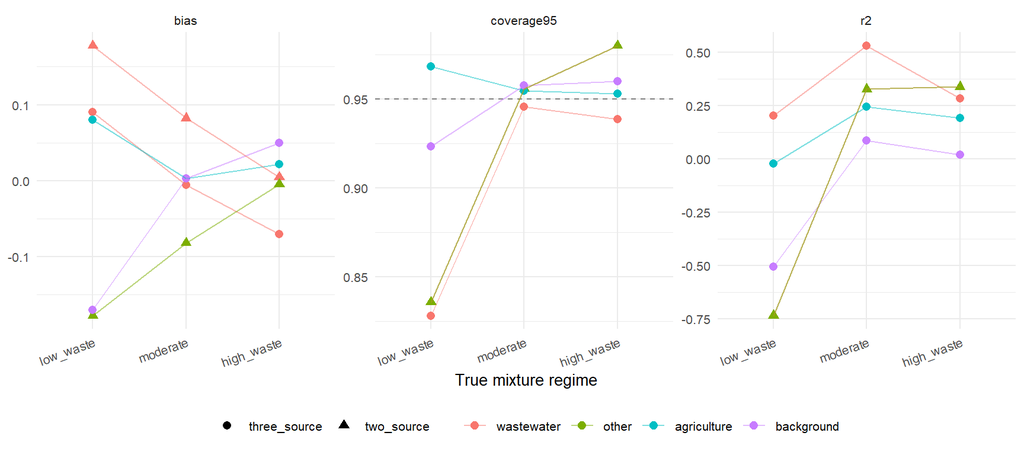

Figure 8

```r
id_met |>
  filter(sigma_a == 0.3, !truth_enrich, !fit_enrich_aware, overlap == "low") |>
  mutate(regime = factor(regime, c("low_waste", "moderate", "high_waste")),
         source = factor(source, c("wastewater", "other", "agriculture", "background"))) |>
  pivot_longer(c(bias, coverage95, r2), names_to = "metric", values_to = "value") |>
  ggplot(aes(regime, value, color = source, shape = structure, group = interaction(source, structure))) +
  geom_hline(data = tibble(metric = "coverage95", y = 0.95), aes(yintercept = y), linetype = "dashed", color = "gray50") +
  geom_point(size = 2.2) + geom_line(alpha = 0.5) +
  facet_wrap(~metric, scales = "free_y") +
  labs(x = "True mixture regime", y = NULL, color = NULL, shape = NULL) +
  theme_minimal(base_size = 10) + theme(legend.position = "bottom", axis.text.x = element_text(angle = 20, hjust = 1))
```

## 3.2 Confident classification and enrichment

A sample is classified by its most probable dominant source, and counts as *confident* if that probability is at least 0.8. A *confident-wrong* call is confident and incorrect. AUC measures how well P(source dominant) ranks truly dominant samples above others (0.5 = chance).

```r
id_cls |>
  filter(regime == "moderate", sigma_a == 0.3, !truth_enrich, !fit_enrich_aware) |>
  select(structure, overlap, confident_rate, accuracy_confident, confident_wrong_rate, any_of(c("auc_ww_vs_other", "auc_ww_vs_ag", "auc_ww_vs_bg", "auc_ag_vs_bg"))) |>
  knitr::kable(digits = 2, caption = "Dominant-source classification (moderate mixtures, no enrichment, analytical SD 0.3).")
```

Dominant-source classification (moderate mixtures, no enrichment, analytical SD 0.3).

| structure | overlap | confident_rate | accuracy_confident | confident_wrong_rate | auc_ww_vs_other | auc_ww_vs_ag | auc_ww_vs_bg | auc_ag_vs_bg |
| --- | --- | --- | --- | --- | --- | --- | --- | --- |
| two_source | low | 0.48 | 0.91 | 0.04 | 0.83 | NA | NA | NA |
| two_source | high | 0.33 | 0.91 | 0.03 | 0.80 | NA | NA | NA |
| three_source | low | 0.12 | 0.93 | 0.01 | NA | 0.88 | 0.83 | 0.61 |
| three_source | high | 0.09 | 0.90 | 0.01 | NA | 0.86 | 0.78 | 0.64 |

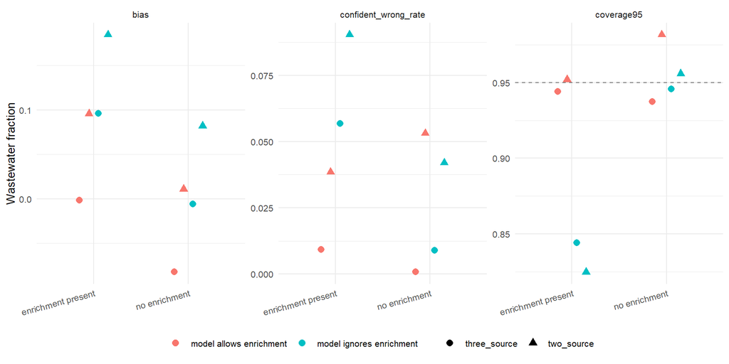

Figure 9

```r
enr <- id_met |>
  filter(source == "wastewater", regime == "moderate", sigma_a == 0.3, overlap == "low") |>
  left_join(select(id_cls, structure, overlap, sigma_a, truth_enrich, regime, fit_enrich_aware, confident_wrong_rate),
            by = c("structure", "overlap", "sigma_a", "truth_enrich", "regime", "fit_enrich_aware")) |>
  mutate(truth = if_else(truth_enrich, "enrichment present", "no enrichment"),
         fit = if_else(fit_enrich_aware, "model allows enrichment", "model ignores enrichment")) |>
  pivot_longer(c(bias, coverage95, confident_wrong_rate), names_to = "metric", values_to = "value")

ggplot(enr, aes(truth, value, color = fit, shape = structure)) +
  geom_hline(data = tibble(metric = "coverage95", y = 0.95), aes(yintercept = y), linetype = "dashed", color = "gray50") +
  geom_point(size = 2.5, position = position_dodge(width = 0.4)) +
  facet_wrap(~metric, scales = "free_y") +
  labs(x = NULL, y = "Wastewater fraction", color = NULL, shape = NULL) +
  theme_minimal(base_size = 10) + theme(legend.position = "bottom", axis.text.x = element_text(angle = 15, hjust = 1))
```

```r
id_met |>
  filter(source == "wastewater", regime == "moderate", !truth_enrich, !fit_enrich_aware, overlap == "low") |>
  select(structure, analytical_sd = sigma_a, rmse, coverage95, ci_width, r2) |>
  knitr::kable(digits = 3, caption = "Effect of analytical error on wastewater-fraction recovery (low overlap, moderate mixtures).")
```

Effect of analytical error on wastewater-fraction recovery (low overlap, moderate mixtures).

| structure | analytical_sd | rmse | coverage95 | ci_width | r2 |
| --- | --- | --- | --- | --- | --- |
| two_source | 0.3 | 0.192 | 0.956 | 0.820 | 0.327 |
| two_source | 1.0 | 0.195 | 0.956 | 0.823 | 0.330 |
| three_source | 0.3 | 0.160 | 0.946 | 0.619 | 0.531 |
| three_source | 1.0 | 0.165 | 0.936 | 0.629 | 0.514 |

## 3.3 Sensitivity to the priors

```r
id_sens |>
  filter(source == "wastewater", sigma_a == 0.3) |>
  select(structure, variant, bias, rmse, coverage95, r2, confident_wrong_rate) |>
  knitr::kable(digits = 2, caption = "Wastewater-fraction recovery when the fitted priors differ from the truth (low overlap, moderate mixtures, no enrichment, analytical SD 0.3).")
```

Wastewater-fraction recovery when the fitted priors differ from the truth (low overlap, moderate mixtures, no enrichment, analytical SD 0.3).

| structure | variant | bias | rmse | coverage95 | r2 | confident_wrong_rate |
| --- | --- | --- | --- | --- | --- | --- |
| two_source | base (Dirichlet 1) | 0.08 | 0.19 | 0.96 | 0.38 | 0.03 |
| two_source | sparser fractions (Dirichlet 0.5) | 0.07 | 0.19 | 0.98 | 0.36 | 0.05 |
| two_source | denser fractions (Dirichlet 2) | 0.10 | 0.20 | 0.86 | 0.27 | 0.02 |
| two_source | source means +2 SE | 0.00 | 0.17 | 0.98 | 0.50 | 0.05 |
| two_source | source means -2 SE | 0.16 | 0.23 | 0.93 | 0.03 | 0.05 |
| two_source | source SDs x1.5 | 0.10 | 0.20 | 0.97 | 0.26 | 0.00 |
| two_source | source SDs x0.67 | 0.05 | 0.19 | 0.89 | 0.37 | 0.07 |
| three_source | base (Dirichlet 1) | 0.00 | 0.16 | 0.94 | 0.55 | 0.01 |
| three_source | sparser fractions (Dirichlet 0.5) | 0.01 | 0.16 | 0.97 | 0.53 | 0.01 |
| three_source | denser fractions (Dirichlet 2) | 0.00 | 0.16 | 0.85 | 0.52 | 0.01 |
| three_source | source means +2 SE | -0.07 | 0.17 | 0.93 | 0.46 | 0.00 |
| three_source | source means -2 SE | 0.08 | 0.18 | 0.92 | 0.43 | 0.04 |
| three_source | source SDs x1.5 | -0.01 | 0.16 | 0.96 | 0.51 | 0.00 |
| three_source | source SDs x0.67 | 0.00 | 0.16 | 0.87 | 0.52 | 0.04 |

## 3.4 What the simulations show

Numbers are for moderate mixtures and analytical SD 0.3 per mil unless stated; all are simulation results, conditional on the literature priors being roughly right.

1. **Per-sample fractions are only weakly identified, even for wastewater vs other.** The two-source posterior mean explains about a third of the variance in true wastewater fraction (r2 = 0.33; 0.18 with the cesspool-like source), and the mean 95% interval spans about 0.8 of the 0 to 1 range. Coverage is near nominal (0.95) only because the intervals are wide. In the three-source model, wastewater r2 is about 0.5, agriculture about 0.24 and background about 0.09.
2. **Analytical error is not the bottleneck.** Moving from 0.3 to 1.0 per mil changes two-source r2 by less than 0.01 and RMSE by about 0.003. Variability within each source (SD about 6.5 per mil for wastewater and 2 to 3 for the others) limits precision, so the lab precision matters little for this question.
3. **Wastewater can be separated from the rest at the level of classification.** Two-source AUC is 0.83 (0.80 with the cesspool-like source); 48% of samples get a confident call (probability at least 0.8) of which about 91% are correct, and 4% of all samples are confident-wrong. In the three-source model wastewater vs agriculture has AUC 0.88 and wastewater vs background 0.83.
4. **Agriculture cannot be separated from background.** Agriculture vs background AUC is 0.61 (0.5 is chance), no sample gets a confident call for either, and agriculture r2 is 0.24 with intervals about 0.7 wide. This is the overlap seen in the literature priors (0.53), not a failure of the sampler.
5. **Unmodelled enrichment is the largest threat.** If nitrate is enriched by 0 to 5 per mil (denitrification-like) and the model ignores it, wastewater fractions are overestimated by about 0.10 (three-source) to 0.19 (two-source), 95% coverage falls to 0.82 to 0.84, and confident-wrong calls rise to 6 to 9%. Allowing for enrichment with the matching prior restores coverage to about 0.95 and cuts confident-wrong calls to 1 to 4%, at the cost of fewer confident calls and a small underestimate when no enrichment occurred. That allowance matched the simulated truth exactly, so the benefit is optimistic.
6. **Mixture regime and priors matter.** When true wastewater fractions are low (mean about 0.16), the two-source estimate is pulled towards 0.5 (bias +0.18) and coverage drops to 0.84; with high-waste mixtures it is 0.98. A denser Dirichlet prior (concentration 2) lowers coverage to 0.85 to 0.86, narrower source SDs to 0.87 to 0.89, and shifting the source means by 2 standard errors moves the wastewater bias by roughly -0.07 to +0.16 (two-source r2 from 0.50 to 0.03).

**Recommendation for the observed-data model.**

- Use the **two-source structure, waste-associated vs other**, as the primary model. Do not use the three-source model as primary. Agriculture (synthetic fertilizer) and background nitrate overlap too much for d15N alone; manure overlaps wastewater, so animal-waste agriculture would fall in the waste class.
- Report **P(waste-associated N dominant)**, and population-level summaries across samples (for example, mean probability by cesspool-exposure class), in preference to single-sample fractions. Per-sample point estimates should not be interpreted as measured fractions.
- Fit the model both with and without an enrichment allowance and show the difference; the unmodelled-enrichment bias is larger than any other effect tested.
- **What this means for the Figure 5 question.** An isotope signal can test whether higher cesspool exposure goes with more waste-like nitrate. It cannot confirm an agricultural contribution, because a lack of waste-like d15N where agriculture is high is equally expected from fertilizer nitrate or natural soil nitrate.
- Still to test in the next step: whether sharing source means across samples and partial pooling by site or watershed improves population-level estimates. This is not tested here.

# 4 Isotope-only Bayesian mixing model

**Question.** Using only d15N and the literature priors, how much of the nitrate in each of the 138 isotope samples (the samples the cached fits were run on) looks waste-associated rather than from other sources? The fractions are estimated without agricultural land cover, the cesspool index, NOx concentration or any GAM result, so they can be compared with those predictors afterwards.

**Structure (from the identifiability study).** Two sources: waste-associated N (W) and other N (O: synthetic fertilizer, soil and marine nitrate pooled). For sample i,

$$y_i \sim \mathrm{Normal}\Big(f_i\,\mu_W + (1-f_i)\,\mu_O + e,\ \sqrt{f_i^2 s_W^2 + (1-f_i)^2 s_O^2 + \sigma_a^2 + \tau_e^2}\Big)$$

with source means
$$\mu_k \sim \mathrm{Normal}(m_k, \mathrm{SE}_k)$$
shared by all samples, source SDs
$$s_k \sim \mathrm{LogNormal}(\log \mathrm{sd}_k, 0.25)$$
taken from Section 2.5, and analytical SD
$$\sigma_a = 0.3$$
per mil (fixed; the lab precision is not yet known). The enrichment allowance adds a shift
$$e$$
and spread
$$\tau_e$$
: none (0, 0) or moderate (2.5, 1.44, equivalent to a denitrification-like shift of Uniform(0, 5) per mil). Two fraction priors are fitted: *independent* (uniform on (0, 1) for every sample), and *pooled* (sample fractions drawn from a Beta distribution with population mean
$$\pi_W$$
and concentration
$$\kappa$$
, still using d15N only). Four chains of 2,000 iterations (independent) or 6,000 (pooled), run with rstan; code in `scripts/isotope_two_source_mixing.stan`, `isotope_two_source_mixing_pooled.stan`, `isotope_04_mixing_model.R` and `isotope_04b_mixing_pooled_and_loo.R`.

```r
mix_dir <- here("output", "isotope", "tables")
mx_diag <- read_csv(file.path(mix_dir, "mix_diagnostics.csv"), show_col_types = FALSE)
mx_par <- read_csv(file.path(mix_dir, "mix_parameter_posteriors.csv"), show_col_types = FALSE)
mx_samp <- read_csv(file.path(mix_dir, "mix_sample_posteriors_all_runs.csv"), show_col_types = FALSE)
mx_runs <- read_csv(file.path(mix_dir, "mix_runs.csv"), show_col_types = FALSE)
mx_ppc <- read_csv(file.path(mix_dir, "mix_ppc_stats.csv"), show_col_types = FALSE)
pl_diag <- read_csv(file.path(mix_dir, "mix_pooled_diagnostics.csv"), show_col_types = FALSE)
pl_par <- read_csv(file.path(mix_dir, "mix_pooled_parameters.csv"), show_col_types = FALSE)
pl_samp <- read_csv(file.path(mix_dir, "mix_pooled_sample_posteriors.csv"), show_col_types = FALSE)
pl_ppc <- read_csv(file.path(mix_dir, "mix_pooled_ppc_stats.csv"), show_col_types = FALSE)
loo_tab <- read_csv(file.path(mix_dir, "mix_loo_marginal_compare.csv"), show_col_types = FALSE)

bind_rows(
  mx_diag |> filter(endmember == "literature (base)", sigma_a == 0.3, enrichment %in% c("none", "moderate")) |>
    transmute(model = "independent", enrichment, n_divergent, max_rhat, min_ess_bulk, min_ess_tail, min_ebfmi),
  pl_diag) |>
  knitr::kable(digits = 2, caption = "Convergence: 4 chains each. Rhat should be near 1, no divergences, ESS in the hundreds or more, E-BFMI above about 0.3.")
```

Convergence: 4 chains each. Rhat should be near 1, no divergences, ESS in the hundreds or more, E-BFMI above about 0.3.

| model | enrichment | n_divergent | max_rhat | min_ess_bulk | min_ess_tail | min_ebfmi |
| --- | --- | --- | --- | --- | --- | --- |
| independent | none | 0 | 1.01 | 1827.35 | 1338.82 | 0.44 |
| independent | moderate | 0 | 1.01 | 3085.87 | 1442.25 | 0.57 |
| pooled | none | 0 | 1.00 | 656.24 | 1482.58 | 0.23 |
| pooled | moderate | 0 | 1.01 | 675.34 | 986.54 | 0.14 |

```r
bind_rows(
  mx_par |> filter(endmember == "literature (base)", sigma_a == 0.3, enrichment %in% c("none", "moderate")) |>
    transmute(model = "independent", enrichment, variable, mean, sd, q2.5, q97.5),
  pl_par |> transmute(model, enrichment, variable, mean, sd, q2.5, q97.5)) |>
  arrange(model, enrichment) |>
  knitr::kable(digits = 2, caption = paste0("Posterior of source and population parameters (per mil, except pi_w and kappa). Priors: mu_w mean ",
    "15.9 (SE 1.7), mu_o 2.1 (SE 0.5), s_w 6.6, s_o 2.8."))
```

Posterior of source and population parameters (per mil, except pi_w and kappa). Priors: mu_w mean 15.9 (SE 1.7), mu_o 2.1 (SE 0.5), s_w 6.6, s_o 2.8.

| model | enrichment | variable | mean | sd | q2.5 | q97.5 |
| --- | --- | --- | --- | --- | --- | --- |
| independent | moderate | mu_w | 10.42 | 0.67 | 9.18 | 11.81 |
| independent | moderate | mu_o | 2.75 | 0.37 | 2.02 | 3.46 |
| independent | moderate | s_w | 4.12 | 0.48 | 3.24 | 5.13 |
| independent | moderate | s_o | 1.84 | 0.33 | 1.27 | 2.54 |
| independent | moderate | mean_f (average of sample fractions) | 0.48 | 0.02 | 0.43 | 0.53 |
| independent | none | mu_w | 13.66 | 0.62 | 12.48 | 14.98 |
| independent | none | mu_o | 3.67 | 0.40 | 2.86 | 4.44 |
| independent | none | s_w | 3.92 | 0.41 | 3.18 | 4.78 |
| independent | none | s_o | 2.12 | 0.38 | 1.43 | 2.90 |
| independent | none | mean_f (average of sample fractions) | 0.51 | 0.02 | 0.46 | 0.56 |
| pooled | moderate | mu_w | 15.86 | 1.62 | 12.80 | 19.12 |
| pooled | moderate | mu_o | 2.61 | 0.47 | 1.69 | 3.53 |
| pooled | moderate | s_w | 5.81 | 0.98 | 4.12 | 7.96 |
| pooled | moderate | s_o | 1.75 | 0.30 | 1.22 | 2.38 |
| pooled | moderate | pi_w | 0.28 | 0.05 | 0.19 | 0.38 |
| pooled | moderate | kappa | 9.00 | 3.87 | 3.79 | 18.60 |
| pooled | none | mu_w | 16.44 | 1.51 | 13.64 | 19.51 |
| pooled | none | mu_o | 2.46 | 0.46 | 1.57 | 3.34 |
| pooled | none | s_w | 4.89 | 0.64 | 3.76 | 6.28 |
| pooled | none | s_o | 2.00 | 0.38 | 1.35 | 2.81 |
| pooled | none | pi_w | 0.46 | 0.06 | 0.36 | 0.57 |
| pooled | none | kappa | 13.18 | 5.11 | 6.30 | 25.43 |

## 4.1 Does the model fit?

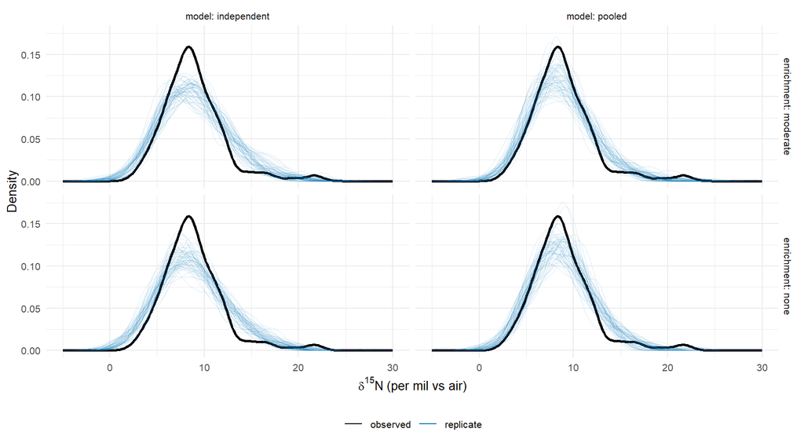

Figure 10

```r
ppc_files <- tribble(~model, ~enrichment, ~file,
  "independent", "none", "mix_ppc_none.rds", "independent", "moderate", "mix_ppc_moderate.rds",
  "pooled", "none", "mix_pooled_ppc_none.rds", "pooled", "moderate", "mix_pooled_ppc_moderate.rds")
ppc_dens <- pmap_dfr(ppc_files, \(model, enrichment, file) {
  o <- readRDS(here("output", "isotope", "model_objects", file))
  xs <- seq(-5, 30, length.out = 200)
  rep <- map_dfr(1:60, \(r) tibble(draw = r, x = xs, d = approxfun(density(o$y_rep[r, ], from = -5, to = 30, n = 200)$x, density(o$y_rep[r, ], from = -5, to = 30, n = 200)$y)(xs)))
  obs <- tibble(x = xs, d = approxfun(density(o$y, from = -5, to = 30, n = 200)$x, density(o$y, from = -5, to = 30, n = 200)$y)(xs))
  bind_rows(mutate(rep, kind = "replicate"), mutate(obs, draw = 0, kind = "observed")) |> mutate(model = model, enrichment = enrichment)
})

ggplot(ppc_dens, aes(x, d, group = interaction(draw, kind), color = kind, alpha = kind, linewidth = kind)) +
  geom_line() +
  scale_color_manual(values = c(replicate = "#0072B2", observed = "black"), name = NULL) +
  scale_alpha_manual(values = c(replicate = 0.15, observed = 1), guide = "none") +
  scale_linewidth_manual(values = c(replicate = 0.3, observed = 0.9), guide = "none") +
  facet_grid(enrichment ~ model, labeller = label_both) +
  labs(x = expression(delta^{15}*N~"(per mil vs air)"), y = "Density") +
  theme_minimal(base_size = 10) + theme(legend.position = "bottom")
```

```r
bind_rows(mx_ppc |> filter(enrichment %in% c("none", "moderate")) |> transmute(model = "independent", enrichment, statistic, observed, rep_mean, ppp),
          pl_ppc) |>
  filter(statistic %in% c("mean", "sd", "min", "max", "frac_gt12", "frac_lt6")) |>
  knitr::kable(digits = 2, caption = "Posterior predictive checks. ppp = share of replicated datasets with a statistic at least as large as observed; values near 0 or 1 flag misfit.")
```

Posterior predictive checks. ppp = share of replicated datasets with a statistic at least as large as observed; values near 0 or 1 flag misfit.

| model | enrichment | statistic | observed | rep_mean | ppp |
| --- | --- | --- | --- | --- | --- |
| independent | none | mean | 8.83 | 8.78 | 0.44 |
| independent | none | sd | 3.21 | 3.67 | 0.95 |
| independent | none | min | 2.80 | 0.75 | 0.03 |
| independent | none | max | 21.70 | 19.91 | 0.18 |
| independent | none | frac_gt12 | 0.11 | 0.19 | 0.99 |
| independent | none | frac_lt6 | 0.15 | 0.23 | 0.99 |
| independent | moderate | mean | 8.83 | 8.92 | 0.60 |
| independent | moderate | sd | 3.21 | 3.62 | 0.91 |
| independent | moderate | min | 2.80 | 0.88 | 0.04 |
| independent | moderate | max | 21.70 | 20.19 | 0.22 |
| independent | moderate | frac_gt12 | 0.11 | 0.19 | 0.99 |
| independent | moderate | frac_lt6 | 0.15 | 0.21 | 0.95 |
| pooled | none | mean | 8.83 | 8.79 | 0.44 |
| pooled | none | sd | 3.21 | 3.22 | 0.50 |
| pooled | none | min | 2.80 | 1.51 | 0.11 |
| pooled | none | max | 21.70 | 18.83 | 0.09 |
| pooled | none | frac_gt12 | 0.11 | 0.16 | 0.93 |
| pooled | none | frac_lt6 | 0.15 | 0.19 | 0.88 |
| pooled | moderate | mean | 8.83 | 8.73 | 0.38 |
| pooled | moderate | sd | 3.21 | 3.30 | 0.61 |
| pooled | moderate | min | 2.80 | 1.28 | 0.08 |
| pooled | moderate | max | 21.70 | 19.71 | 0.19 |
| pooled | moderate | frac_gt12 | 0.11 | 0.15 | 0.93 |
| pooled | moderate | frac_lt6 | 0.15 | 0.20 | 0.91 |

```r
loo_tab |> select(model, elpd_diff, se_diff, elpd_loo, p_loo) |>
  knitr::kable(digits = 1, caption = "Leave-one-out comparison with the sample fractions integrated out (higher elpd is better).")
```

Leave-one-out comparison with the sample fractions integrated out (higher elpd is better).

| model | elpd_diff | se_diff | elpd_loo | p_loo |
| --- | --- | --- | --- | --- |
| pooled_moderate | 0.0 | 0.0 | -348.7 | 2.5 |
| pooled_none | -1.4 | 1.0 | -350.1 | 2.6 |
| independent_moderate | -4.3 | 1.9 | -353.0 | 1.9 |
| independent_none | -10.2 | 2.5 | -358.9 | 2.0 |

## 4.2 Sample-level posteriors

```r
mx_prim <- read_csv(file.path(mix_dir, "mix_sample_posteriors_primary.csv"), show_col_types = FALSE) |>
  transmute(model = "independent", enrichment, sample_id, N15, island, f_mean, f_lwr, f_upr, p_gt10, p_gt20, p_gt50)
mx_all <- bind_rows(mx_prim, pl_samp |> select(model, enrichment, sample_id, N15, f_mean, f_lwr, f_upr, p_gt10, p_gt20, p_gt50))

mx_all |>
  group_by(model, enrichment) |>
  arrange(N15, .by_group = TRUE) |>
  summarise(mean_f = mean(f_mean), median_ci_width = median(f_upr - f_lwr),
            d15N_at_p20 = approx(p_gt50, N15, 0.2, ties = mean)$y, d15N_at_p50 = approx(p_gt50, N15, 0.5, ties = mean)$y,
            d15N_at_p80 = approx(p_gt50, N15, 0.8, ties = mean)$y,
            n_conf_waste = sum(p_gt50 >= 0.8), n_conf_other = sum(p_gt50 <= 0.2), n_unresolved = sum(p_gt50 > 0.2 & p_gt50 < 0.8),
            .groups = "drop") |>
  knitr::kable(digits = 2, caption = paste0("Sample-level summary (", n_fit, " samples). P(waste dominant) = P(f > 0.5). n_conf_waste = samples with P >= 0.8; ",
    "n_conf_other = P <= 0.2. d15N_at_pXX = d15N at which P(waste dominant) = 0.2, 0.5, 0.8."))
```

Sample-level summary (138 samples). P(waste dominant) = P(f > 0.5). n_conf_waste = samples with P >= 0.8; n_conf_other = P <= 0.2. d15N_at_pXX = d15N at which P(waste dominant) = 0.2, 0.5, 0.8.

| model | enrichment | mean_f | median_ci_width | d15N_at_p20 | d15N_at_p50 | d15N_at_p80 | n_conf_waste | n_conf_other | n_unresolved |
| --- | --- | --- | --- | --- | --- | --- | --- | --- | --- |
| independent | moderate | 0.48 | 0.90 | 4.81 | 9.32 | 12.20 | 13 | 13 | 112 |
| independent | none | 0.51 | 0.81 | 6.19 | 8.54 | 10.72 | 28 | 24 | 86 |
| pooled | moderate | 0.28 | 0.50 | 12.57 | 16.40 | 20.44 | 2 | 129 | 7 |
| pooled | none | 0.46 | 0.49 | 6.50 | 10.52 | 14.19 | 9 | 30 | 99 |

```r
write_csv(mx_all, here("output", "isotope", "tables", "mix_sample_posteriors_four_variants.csv"))
```

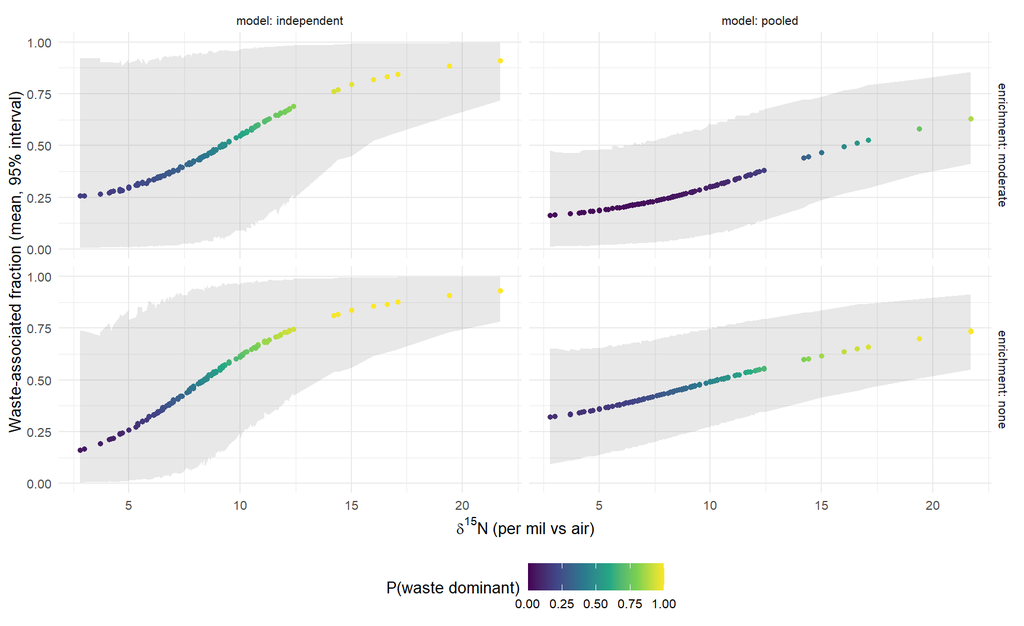

Figure 11

```r
ggplot(mx_all, aes(N15, f_mean)) +
  geom_ribbon(aes(ymin = f_lwr, ymax = f_upr), alpha = 0.15, fill = "gray40") +
  geom_point(aes(color = p_gt50), size = 1.3) +
  scale_color_viridis_c(name = "P(waste dominant)", limits = c(0, 1)) +
  facet_grid(enrichment ~ model, labeller = label_both) +
  labs(x = expression(delta^{15}*N~"(per mil vs air)"), y = "Waste-associated fraction (mean, 95% interval)") +
  theme_minimal(base_size = 10) + theme(legend.position = "bottom")
```

## 4.3 Sensitivity to endmembers and enrichment

```r
ref <- mx_samp |> filter(run_id %in% c(1, 2)) |> transmute(enr = if_else(run_id == 1, "none", "moderate"), sample_id, ref_p = p_gt50)
mx_samp |>
  left_join(mx_runs, by = "run_id") |>
  mutate(enr = if_else(enrichment == "none", "none", "moderate")) |>
  left_join(ref, by = c("enr", "sample_id")) |>
  group_by(run_id, endmember, enrichment, sigma_a) |>
  summarise(mean_f = mean(f_mean), n_conf_waste = sum(p_gt50 >= 0.8), n_conf_other = sum(p_gt50 <= 0.2),
            rank_corr_with_base = cor(p_gt50, ref_p, method = "spearman"), .groups = "drop") |>
  knitr::kable(digits = 2, caption = "Independent-fraction model across endmember, enrichment and analytical-error variants (rank_corr_with_base compares P(waste dominant) with the base fit that has the same enrichment setting; for the weak and strong enrichment runs the comparison is with the moderate fit).")
```

Independent-fraction model across endmember, enrichment and analytical-error variants (rank_corr_with_base compares P(waste dominant) with the base fit that has the same enrichment setting; for the weak and strong enrichment runs the comparison is with the moderate fit).

| run_id | endmember | enrichment | sigma_a | mean_f | n_conf_waste | n_conf_other | rank_corr_with_base |
| --- | --- | --- | --- | --- | --- | --- | --- |
| 1 | literature (base) | none | 0.3 | 0.51 | 28 | 24 | 1.00 |
| 2 | literature (base) | moderate | 0.3 | 0.48 | 13 | 13 | 1.00 |
| 3 | cesspool-like waste N(11, 4.5) | none | 0.3 | 0.52 | 34 | 21 | 1.00 |
| 4 | cesspool-like waste N(11, 4.5) | moderate | 0.3 | 0.49 | 17 | 7 | 1.00 |
| 5 | source means +2 SE | none | 0.3 | 0.49 | 24 | 30 | 1.00 |
| 6 | source means +2 SE | moderate | 0.3 | 0.47 | 9 | 3 | 1.00 |
| 7 | source means -2 SE | none | 0.3 | 0.54 | 35 | 19 | 1.00 |
| 8 | source means -2 SE | moderate | 0.3 | 0.50 | 18 | 12 | 1.00 |
| 9 | source SDs x1.5 | none | 0.3 | 0.51 | 23 | 19 | 1.00 |
| 10 | source SDs x1.5 | moderate | 0.3 | 0.48 | 9 | 2 | 1.00 |
| 11 | source SDs x0.67 | none | 0.3 | 0.51 | 34 | 31 | 1.00 |
| 12 | source SDs x0.67 | moderate | 0.3 | 0.48 | 19 | 20 | 1.00 |
| 13 | literature (base) | weak | 0.3 | 0.49 | 22 | 21 | 1.00 |
| 14 | literature (base) | strong | 0.3 | 0.47 | 6 | 0 | 0.99 |
| 15 | literature (base) | none | 1.0 | 0.51 | 25 | 21 | 1.00 |
| 16 | literature (base) | moderate | 1.0 | 0.48 | 10 | 10 | 1.00 |

### 4.3.1 What the model says

**Use in the next step.** Because the sample-level results are essentially re-expressed d15N, the comparison with cesspool exposure and agriculture should be run with the fractions kept as latent variables (or posterior draws propagated), under both enrichment settings, and judged mainly by whether the direction of the association survives. Posterior draws of the fractions are saved in `output/isotope/model_objects/mix_draws_f_*.rds`; sample summaries in `output/isotope/tables/mix_sample_posteriors_*.csv`.

# 5 Does the waste-associated fraction track land use?

**Question.** Does the isotope-derived waste-associated fraction rise with cesspool exposure, and how does it relate to agriculture, NOx concentration and rainfall? Only d15N sets the fractions; land use is used only as a predictor. Two analyses carry the isotope uncertainty into the effect estimates (code: `scripts/isotope_05_land_use_tests.R`):

- **Joint model (primary).** The mixing model of Section 4 is fitted together with a regression: the logit of each sample’s waste fraction is a linear function of standardized predictors (the same z-scores as the GAM), island (Oʻahu is the reference), an ahupuaʻa random intercept and a sample-level residual. Coefficients have Normal(0, 1) priors on the logit scale. Estimates are reported per standard deviation of the predictor on the logit scale (
  $$\beta$$
  ) with 95% credible intervals and P(
  $$\beta$$
  > 0); the change in the waste fraction of a sample with median random effects is also given. It is fitted with no enrichment allowance and with the moderate allowance from the previous step.
- **Modular repeated-draw analysis (conservative check).** 300 draws of the fractions from the isotope-only independent model are each regressed (logit scale, ahupuaʻa-clustered standard errors) on the same predictors and pooled with Rubin’s rules, so the isotope uncertainty enters through the between-draw variance. Those draws ignore the covariates, so this approach is expected to be attenuated; it keeps the isotope-only estimates untouched.

Prespecified models: M1 = cesspool + agriculture; M2 = M1 + log NOx; M3 = M1 + storm rainfall; M4a and M4b add rainfall x cesspool and rainfall x agriculture separately (the two interactions are not fitted together, given 138 samples and 56 ahupuaʻa).

```r
lu_joint <- read_csv(file.path(mix_dir, "lu_joint_effects.csv"), show_col_types = FALSE)
lu_mod <- read_csv(file.path(mix_dir, "lu_modular_effects.csv"), show_col_types = FALSE)
lu_perm <- read_csv(file.path(mix_dir, "lu_permutation_null.csv"), show_col_types = FALSE)
lu_cor <- read_csv(file.path(mix_dir, "lu_unadjusted_rank_correlations.csv"), show_col_types = FALSE)

lu_terms <- c("z_log_cess_exposure", "z_pct_agriculture", "z_log_NOx", "z_chirps_storm_cumulative_mm", "rain_x_cess", "rain_x_ag")

lu_joint |>
  filter(term %in% lu_terms) |>
  select(model, enrichment, term, beta_mean, beta_lwr, beta_upr, p_positive, dfrac_mean) |>
  knitr::kable(digits = 2, caption = "Joint model: effect on the logit of the waste-associated fraction per SD of the predictor (95% credible interval, P(beta > 0), and change in the fraction for a median sample).")
```

Joint model: effect on the logit of the waste-associated fraction per SD of the predictor (95% credible interval, P(beta > 0), and change in the fraction for a median sample).

| model | enrichment | term | beta_mean | beta_lwr | beta_upr | p_positive | dfrac_mean |
| --- | --- | --- | --- | --- | --- | --- | --- |
| M1_cess_ag | none | z_log_cess_exposure | 0.18 | -0.03 | 0.42 | 0.96 | 0.04 |
| M1_cess_ag | none | z_pct_agriculture | -0.23 | -0.45 | 0.00 | 0.02 | -0.05 |
| M1_cess_ag | moderate | z_log_cess_exposure | 0.27 | -0.02 | 0.59 | 0.97 | 0.05 |
| M1_cess_ag | moderate | z_pct_agriculture | -0.38 | -0.86 | -0.02 | 0.02 | -0.06 |
| M2_plus_NOx | none | z_log_cess_exposure | 0.14 | -0.06 | 0.36 | 0.92 | 0.03 |
| M2_plus_NOx | none | z_pct_agriculture | -0.23 | -0.47 | -0.01 | 0.02 | -0.06 |
| M2_plus_NOx | none | z_log_NOx | 0.31 | 0.10 | 0.58 | 1.00 | 0.07 |
| M2_plus_NOx | moderate | z_log_cess_exposure | 0.22 | -0.06 | 0.54 | 0.94 | 0.04 |
| M2_plus_NOx | moderate | z_pct_agriculture | -0.42 | -0.90 | -0.05 | 0.01 | -0.06 |
| M2_plus_NOx | moderate | z_log_NOx | 0.39 | 0.11 | 0.72 | 1.00 | 0.08 |
| M3_plus_rain | none | z_log_cess_exposure | 0.18 | -0.03 | 0.43 | 0.95 | 0.04 |
| M3_plus_rain | none | z_pct_agriculture | -0.24 | -0.48 | -0.01 | 0.02 | -0.06 |
| M3_plus_rain | none | z_chirps_storm_cumulative_mm | 0.13 | -0.21 | 0.50 | 0.77 | 0.03 |
| M3_plus_rain | moderate | z_log_cess_exposure | 0.26 | -0.03 | 0.59 | 0.96 | 0.05 |
| M3_plus_rain | moderate | z_pct_agriculture | -0.40 | -0.87 | -0.03 | 0.02 | -0.06 |
| M3_plus_rain | moderate | z_chirps_storm_cumulative_mm | 0.14 | -0.30 | 0.60 | 0.74 | 0.03 |
| M4a_rain_x_cess | none | z_log_cess_exposure | 0.22 | -0.03 | 0.54 | 0.96 | 0.05 |
| M4a_rain_x_cess | none | z_pct_agriculture | -0.25 | -0.52 | -0.01 | 0.02 | -0.06 |
| M4a_rain_x_cess | none | z_chirps_storm_cumulative_mm | 0.10 | -0.30 | 0.53 | 0.68 | 0.02 |
| M4a_rain_x_cess | none | rain_x_cess | 0.13 | -0.30 | 0.63 | 0.73 | 0.03 |
| M4a_rain_x_cess | moderate | z_log_cess_exposure | 0.29 | -0.03 | 0.65 | 0.96 | 0.05 |
| M4a_rain_x_cess | moderate | z_pct_agriculture | -0.40 | -0.89 | 0.00 | 0.02 | -0.06 |
| M4a_rain_x_cess | moderate | z_chirps_storm_cumulative_mm | 0.11 | -0.41 | 0.66 | 0.66 | 0.02 |
| M4a_rain_x_cess | moderate | rain_x_cess | 0.07 | -0.49 | 0.67 | 0.61 | 0.02 |
| M4b_rain_x_ag | none | z_log_cess_exposure | 0.18 | -0.03 | 0.42 | 0.95 | 0.04 |
| M4b_rain_x_ag | none | z_pct_agriculture | -0.24 | -0.59 | 0.14 | 0.09 | -0.06 |
| M4b_rain_x_ag | none | z_chirps_storm_cumulative_mm | 0.14 | -0.27 | 0.60 | 0.74 | 0.03 |
| M4b_rain_x_ag | none | rain_x_ag | 0.02 | -0.56 | 0.65 | 0.51 | 0.00 |
| M4b_rain_x_ag | moderate | z_log_cess_exposure | 0.28 | -0.03 | 0.65 | 0.96 | 0.05 |
| M4b_rain_x_ag | moderate | z_pct_agriculture | -0.40 | -1.00 | 0.12 | 0.06 | -0.06 |
| M4b_rain_x_ag | moderate | z_chirps_storm_cumulative_mm | 0.19 | -0.48 | 0.88 | 0.72 | 0.04 |
| M4b_rain_x_ag | moderate | rain_x_ag | 0.10 | -0.89 | 1.13 | 0.58 | 0.03 |

```r
lu_joint |>
  distinct(model, enrichment, n_divergent, max_rhat, min_ess_bulk, min_ebfmi) |>
  knitr::kable(digits = 2, caption = "Joint-model convergence (4 chains, 3,000 iterations).")
```

Joint-model convergence (4 chains, 3,000 iterations).

| model | enrichment | n_divergent | max_rhat | min_ess_bulk | min_ebfmi |
| --- | --- | --- | --- | --- | --- |
| M1_cess_ag | none | 0 | 1.01 | 554.67 | 0.60 |
| M1_cess_ag | moderate | 0 | 1.00 | 701.19 | 0.69 |
| M2_plus_NOx | none | 0 | 1.00 | 840.21 | 0.59 |
| M2_plus_NOx | moderate | 0 | 1.01 | 838.17 | 0.66 |
| M3_plus_rain | none | 0 | 1.00 | 668.03 | 0.58 |
| M3_plus_rain | moderate | 0 | 1.00 | 675.46 | 0.67 |
| M4a_rain_x_cess | none | 0 | 1.01 | 865.19 | 0.56 |
| M4a_rain_x_cess | moderate | 0 | 1.01 | 860.56 | 0.69 |
| M4b_rain_x_ag | none | 0 | 1.01 | 571.99 | 0.54 |
| M4b_rain_x_ag | moderate | 0 | 1.00 | 861.50 | 0.73 |

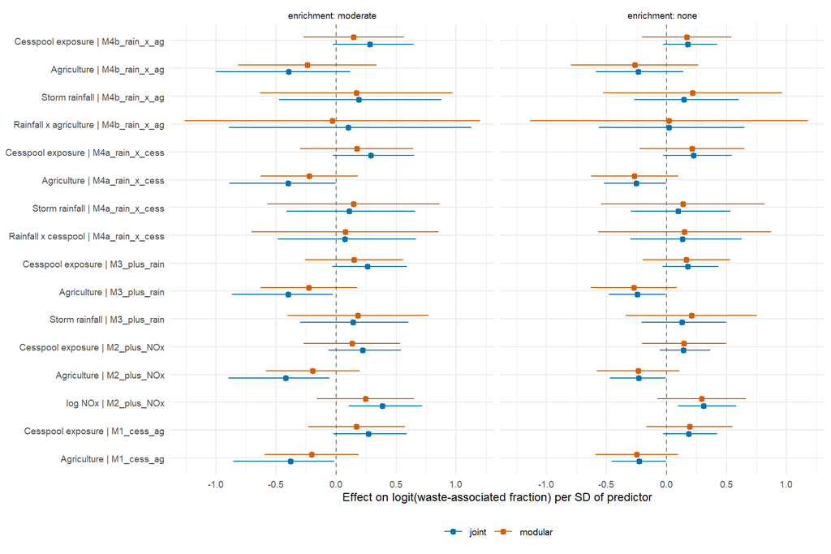

Figure 12

```r
forest <- bind_rows(
  lu_joint |> filter(term %in% lu_terms) |> transmute(analysis = "joint", model, enrichment, term, est = beta_mean, lwr = beta_lwr, upr = beta_upr),
  lu_mod |> filter(term %in% lu_terms) |> transmute(analysis = "modular", model, enrichment, term, est = estimate, lwr, upr)) |>
  mutate(term = factor(term, rev(lu_terms), labels = rev(c("Cesspool exposure", "Agriculture", "log NOx", "Storm rainfall", "Rainfall x cesspool", "Rainfall x agriculture"))),
         label = paste(term, "|", model))

ggplot(forest, aes(est, interaction(term, model, sep = " | "), color = analysis, xmin = lwr, xmax = upr)) +
  geom_vline(xintercept = 0, linetype = "dashed", color = "gray50") +
  geom_pointrange(position = position_dodge(width = 0.5), size = 0.35) +
  facet_wrap(~enrichment, labeller = label_both) +
  scale_color_manual(values = c(joint = "#0072B2", modular = "#D55E00"), name = NULL) +
  labs(x = "Effect on logit(waste-associated fraction) per SD of predictor", y = NULL) +
  theme_minimal(base_size = 9) + theme(legend.position = "bottom")
```

```r
lu_mod |> filter(term %in% lu_terms) |>
  select(model, enrichment, term, estimate, lwr, upr, p_two_sided, share_variance_from_isotopes = frac_between) |>
  knitr::kable(digits = 2, caption = "Modular repeated-draw analysis (pooled over 300 draws; clustered standard errors).")
```

Modular repeated-draw analysis (pooled over 300 draws; clustered standard errors).

| model | enrichment | term | estimate | lwr | upr | p_two_sided | share_variance_from_isotopes |
| --- | --- | --- | --- | --- | --- | --- | --- |
| M1_cess_ag | none | z_log_cess_exposure | 0.19 | -0.17 | 0.55 | 0.30 | 0.40 |
| M1_cess_ag | none | z_pct_agriculture | -0.25 | -0.59 | 0.10 | 0.16 | 0.46 |
| M2_plus_NOx | none | z_log_cess_exposure | 0.15 | -0.20 | 0.50 | 0.41 | 0.42 |
| M2_plus_NOx | none | z_pct_agriculture | -0.24 | -0.58 | 0.11 | 0.18 | 0.45 |
| M2_plus_NOx | none | z_log_NOx | 0.29 | -0.08 | 0.66 | 0.12 | 0.38 |
| M3_plus_rain | none | z_log_cess_exposure | 0.17 | -0.20 | 0.53 | 0.37 | 0.41 |
| M3_plus_rain | none | z_pct_agriculture | -0.27 | -0.63 | 0.08 | 0.13 | 0.45 |
| M3_plus_rain | none | z_chirps_storm_cumulative_mm | 0.21 | -0.34 | 0.76 | 0.45 | 0.43 |
| M4a_rain_x_cess | none | z_log_cess_exposure | 0.21 | -0.23 | 0.65 | 0.34 | 0.38 |
| M4a_rain_x_cess | none | z_pct_agriculture | -0.27 | -0.63 | 0.10 | 0.15 | 0.44 |
| M4a_rain_x_cess | none | z_chirps_storm_cumulative_mm | 0.14 | -0.54 | 0.82 | 0.69 | 0.35 |
| M4a_rain_x_cess | none | rain_x_cess | 0.15 | -0.57 | 0.87 | 0.68 | 0.37 |
| M4b_rain_x_ag | none | z_log_cess_exposure | 0.17 | -0.21 | 0.54 | 0.38 | 0.40 |
| M4b_rain_x_ag | none | z_pct_agriculture | -0.27 | -0.79 | 0.26 | 0.33 | 0.41 |
| M4b_rain_x_ag | none | z_chirps_storm_cumulative_mm | 0.22 | -0.53 | 0.96 | 0.57 | 0.39 |
| M4b_rain_x_ag | none | rain_x_ag | 0.02 | -1.14 | 1.18 | 0.97 | 0.34 |
| M1_cess_ag | moderate | z_log_cess_exposure | 0.17 | -0.23 | 0.57 | 0.41 | 0.44 |
| M1_cess_ag | moderate | z_pct_agriculture | -0.20 | -0.60 | 0.19 | 0.31 | 0.52 |
| M2_plus_NOx | moderate | z_log_cess_exposure | 0.13 | -0.27 | 0.54 | 0.52 | 0.46 |
| M2_plus_NOx | moderate | z_pct_agriculture | -0.19 | -0.58 | 0.20 | 0.33 | 0.52 |
| M2_plus_NOx | moderate | z_log_NOx | 0.25 | -0.16 | 0.65 | 0.23 | 0.45 |
| M3_plus_rain | moderate | z_log_cess_exposure | 0.15 | -0.26 | 0.56 | 0.48 | 0.44 |
| M3_plus_rain | moderate | z_pct_agriculture | -0.23 | -0.63 | 0.18 | 0.27 | 0.51 |
| M3_plus_rain | moderate | z_chirps_storm_cumulative_mm | 0.18 | -0.40 | 0.77 | 0.54 | 0.46 |
| M4a_rain_x_cess | moderate | z_log_cess_exposure | 0.17 | -0.30 | 0.64 | 0.48 | 0.41 |
| M4a_rain_x_cess | moderate | z_pct_agriculture | -0.22 | -0.63 | 0.18 | 0.28 | 0.50 |
| M4a_rain_x_cess | moderate | z_chirps_storm_cumulative_mm | 0.15 | -0.57 | 0.86 | 0.69 | 0.41 |
| M4a_rain_x_cess | moderate | rain_x_cess | 0.08 | -0.70 | 0.85 | 0.85 | 0.43 |
| M4b_rain_x_ag | moderate | z_log_cess_exposure | 0.15 | -0.27 | 0.57 | 0.49 | 0.43 |
| M4b_rain_x_ag | moderate | z_pct_agriculture | -0.24 | -0.82 | 0.34 | 0.42 | 0.46 |
| M4b_rain_x_ag | moderate | z_chirps_storm_cumulative_mm | 0.17 | -0.63 | 0.97 | 0.68 | 0.45 |
| M4b_rain_x_ag | moderate | rain_x_ag | -0.03 | -1.26 | 1.20 | 0.96 | 0.40 |

```r
obs_m1 <- lu_joint |> filter(model == "M1_cess_ag", term %in% c("z_log_cess_exposure", "z_pct_agriculture")) |>
  select(enrichment, term, obs_beta = beta_mean, obs_p_positive = p_positive)
lu_perm |>
  group_by(enrichment, term) |>
  summarise(null_sd_of_posterior_means = sd(beta_mean), null_mean_posterior_sd = mean(beta_sd),
            n_perm = n(), n_P_ge_0.95 = sum(p_positive >= 0.95), n_P_le_0.05 = sum(p_positive <= 0.05), .groups = "drop") |>
  left_join(obs_m1, by = c("enrichment", "term")) |>
  left_join(lu_perm |> left_join(obs_m1, by = c("enrichment", "term")) |> group_by(enrichment, term) |>
              summarise(share_null_abs_beta_ge_observed = mean(abs(beta_mean) >= abs(obs_beta)), .groups = "drop"), by = c("enrichment", "term")) |>
  knitr::kable(digits = 2, caption = paste0("Permutation null for M1: d15N shuffled across samples (10 shuffles per enrichment setting), covariates and sites unchanged. ",
    "With only 10 shuffles the null shares have a resolution of 0.1."))
```

Permutation null for M1: d15N shuffled across samples (10 shuffles per enrichment setting), covariates and sites unchanged. With only 10 shuffles the null shares have a resolution of 0.1.

| enrichment | term | null_sd_of_posterior_means | null_mean_posterior_sd | n_perm | n_P_ge_0.95 | n_P_le_0.05 | obs_beta | obs_p_positive | share_null_abs_beta_ge_observed |
| --- | --- | --- | --- | --- | --- | --- | --- | --- | --- |
| moderate | z_log_cess_exposure | 0.07 | 0.16 | 10 | 0 | 0 | 0.27 | 0.97 | 0 |
| moderate | z_pct_agriculture | 0.11 | 0.17 | 10 | 0 | 0 | -0.38 | 0.02 | 0 |
| none | z_log_cess_exposure | 0.05 | 0.11 | 10 | 0 | 0 | 0.18 | 0.96 | 0 |
| none | z_pct_agriculture | 0.08 | 0.12 | 10 | 0 | 0 | -0.23 | 0.02 | 0 |

```r
lu_cor |> knitr::kable(digits = 2, caption = "Unadjusted Spearman correlation of the sample posterior-mean waste fraction with each predictor (all variants).")
```

Unadjusted Spearman correlation of the sample posterior-mean waste fraction with each predictor (all variants).

| model | enrichment | z_log_cess_exposure | z_pct_agriculture | z_chirps_storm_cumulative_mm | z_log_NOx |
| --- | --- | --- | --- | --- | --- |
| independent | moderate | 0.17 | -0.21 | 0.06 | 0.24 |
| independent | none | 0.17 | -0.21 | 0.07 | 0.24 |
| pooled | moderate | 0.17 | -0.21 | 0.06 | 0.24 |
| pooled | none | 0.17 | -0.21 | 0.07 | 0.24 |

## 5.1 Comparison with the GAM

```r
pick <- \(m, t, e, d = lu_joint) {
  r <- d[d$model == m & d$term == t & d$enrichment == e, ]
  sprintf("%.2f [%.2f, %.2f], P(>0) = %.2f", r$beta_mean, r$beta_lwr, r$beta_upr, r$p_positive)
}
pickm <- \(m, t, e) { r <- lu_mod[lu_mod$model == m & lu_mod$term == t & lu_mod$enrichment == e, ]; sprintf("%.2f [%.2f, %.2f]", r$estimate, r$lwr, r$upr) }

tribble(
  ~gam_finding, ~gam_effect, ~isotope_quantity, ~joint_none, ~joint_moderate, ~modular_none, ~verdict,
  "NOx rises with cesspool exposure", "+0.14 [0.01, 0.26]", "waste fraction vs cesspool exposure",
    pick("M1_cess_ag", "z_log_cess_exposure", "none"), pick("M1_cess_ag", "z_log_cess_exposure", "moderate"), pickm("M1_cess_ag", "z_log_cess_exposure", "none"),
    "Suggestive: positive, interval touches zero; inconclusive in the conservative check",
  "NOx rises with agricultural land cover", "+0.46 [0.11, 0.81]", "waste fraction vs agriculture",
    pick("M1_cess_ag", "z_pct_agriculture", "none"), pick("M1_cess_ag", "z_pct_agriculture", "moderate"), pickm("M1_cess_ag", "z_pct_agriculture", "none"),
    "Not testable as stated: waste fraction falls where agriculture is high, which fits fertilizer-like or soil nitrate but cannot confirm it",
  "NOx rises with rainfall x cesspool", "+0.20 [0.07, 0.33]", "waste fraction vs rainfall x cesspool",
    pick("M4a_rain_x_cess", "rain_x_cess", "none"), pick("M4a_rain_x_cess", "rain_x_cess", "moderate"), pickm("M4a_rain_x_cess", "rain_x_cess", "none"),
    "Inconclusive: centred near zero, wide interval",
  "NOx rises with rainfall x agriculture", "+0.66 [0.24, 1.08]", "waste fraction vs rainfall x agriculture",
    pick("M4b_rain_x_ag", "rain_x_ag", "none"), pick("M4b_rain_x_ag", "rain_x_ag", "moderate"), pickm("M4b_rain_x_ag", "rain_x_ag", "none"),
    "Inconclusive, and not a waste-fraction question",
  "(isotope-only) waste fraction vs NOx", "-", "waste fraction vs log NOx",
    pick("M2_plus_NOx", "z_log_NOx", "none"), pick("M2_plus_NOx", "z_log_NOx", "moderate"), pickm("M2_plus_NOx", "z_log_NOx", "none"),
    "Suggestive: waste-like d15N is more likely at higher NOx; modular check inconclusive"
) |>
  knitr::kable(caption = "GAM findings (standardized effects on log NOx, Figure 5 model) against the isotope-based tests (effects on the logit of the waste fraction per SD; 95% credible intervals).")
```

GAM findings (standardized effects on log NOx, Figure 5 model) against the isotope-based tests (effects on the logit of the waste fraction per SD; 95% credible intervals).

| gam_finding | gam_effect | isotope_quantity | joint_none | joint_moderate | modular_none | verdict |
| --- | --- | --- | --- | --- | --- | --- |
| NOx rises with cesspool exposure | +0.14 [0.01, 0.26] | waste fraction vs cesspool exposure | 0.18 [-0.03, 0.42], P(>0) = 0.96 | 0.27 [-0.02, 0.59], P(>0) = 0.97 | 0.19 [-0.17, 0.55] | Suggestive: positive, interval touches zero; inconclusive in the conservative check |
| NOx rises with agricultural land cover | +0.46 [0.11, 0.81] | waste fraction vs agriculture | -0.23 [-0.45, -0.00], P(>0) = 0.02 | -0.38 [-0.86, -0.02], P(>0) = 0.02 | -0.25 [-0.59, 0.10] | Not testable as stated: waste fraction falls where agriculture is high, which fits fertilizer-like or soil nitrate but cannot confirm it |
| NOx rises with rainfall x cesspool | +0.20 [0.07, 0.33] | waste fraction vs rainfall x cesspool | 0.13 [-0.30, 0.63], P(>0) = 0.73 | 0.07 [-0.49, 0.67], P(>0) = 0.61 | 0.15 [-0.57, 0.87] | Inconclusive: centred near zero, wide interval |
| NOx rises with rainfall x agriculture | +0.66 [0.24, 1.08] | waste fraction vs rainfall x agriculture | 0.02 [-0.56, 0.65], P(>0) = 0.51 | 0.10 [-0.89, 1.13], P(>0) = 0.58 | 0.02 [-1.14, 1.18] | Inconclusive, and not a waste-fraction question |
| (isotope-only) waste fraction vs NOx | - | waste fraction vs log NOx | 0.31 [0.10, 0.58], P(>0) = 1.00 | 0.39 [0.11, 0.72], P(>0) = 1.00 | 0.29 [-0.08, 0.66] | Suggestive: waste-like d15N is more likely at higher NOx; modular check inconclusive |

### 5.1.1 What the tests show

# 6 Probability that nitrate is agriculture-derived: a three-source model

**Question.** The two-source model of Section 4 gives P(waste-associated N dominates), the cesspool-side question. This section adds the agriculture-side question: what is the probability that a sample’s nitrate is fertilizer-derived, and does it rise with agricultural land cover? Code: `scripts/isotope_08_three_source_agriculture.R`, `isotope_three_source_mixing.stan` and `isotope_three_source_mixing_covariates.stan`. Everything in this section is fitted to the same 138 isotope samples as the earlier Bayesian sections.

**Sources.** Waste (literature wastewater, mean 15.9 per mil), synthetic fertilizer (0.3 per mil) and background (soil plus marine nitrate pooled, 3.0 per mil), with the SDs and uncertainties of Section 2.5. Manure is not a separate source: it overlaps wastewater (Section 2.7), so animal-waste agriculture would load on the waste source, not on fertilizer. “Agriculture” here therefore means *synthetic-fertilizer-like* nitrate only.

**Models.** (A) *Isotope-only*: each sample has its own source fractions with a uniform Dirichlet(1, 1, 1) prior and no covariates, giving sample-level P(fertilizer largest), P(fertilizer fraction > 0.5) and the same for waste. (B) *Joint regression*: multinomial-logit fractions with background as the reference; the waste-vs-background and fertilizer-vs-background log-ratios each depend on cesspool exposure and agriculture (standardized, as in the GAM), island, an ahupuaʻa random intercept and a sample-level residual, fitted together with the mixing model (Normal(0, 1) priors on coefficients). (C) *Permutation null* for (B): d15N shuffled across samples (8 shuffles per enrichment setting). Each model is run with no enrichment allowance and with the moderate allowance used earlier.

```r
ag_dir <- here("output", "isotope", "tables")
ag_iso <- read_csv(file.path(ag_dir, "ag3_iso_sample_posteriors.csv"), show_col_types = FALSE)
ag_joint <- read_csv(file.path(ag_dir, "ag3_joint_effects.csv"), show_col_types = FALSE)
ag_dfrac <- read_csv(file.path(ag_dir, "ag3_joint_dfrac.csv"), show_col_types = FALSE)
ag_perm <- read_csv(file.path(ag_dir, "ag3_permutation_null.csv"), show_col_types = FALSE)
ag_diag <- bind_rows(
  read_csv(file.path(ag_dir, "ag3_iso_diagnostics.csv"), show_col_types = FALSE) |> mutate(model = "isotope-only", .before = 1),
  ag_joint |> distinct(enrichment, n_divergent, max_rhat, min_ess_bulk, min_ebfmi) |> mutate(model = "joint", .before = 1))
ag_ppc <- bind_rows(
  read_csv(file.path(ag_dir, "ag3_iso_ppc.csv"), show_col_types = FALSE) |> mutate(model = "isotope-only", .before = 1),
  read_csv(file.path(ag_dir, "ag3_joint_ppc.csv"), show_col_types = FALSE) |> mutate(model = "joint", .before = 1))

ag_diag |> knitr::kable(digits = 2, caption = "Convergence (4 chains each).")
```

Convergence (4 chains each).

| model | enrichment | n_divergent | max_rhat | min_ess_bulk | min_ebfmi |
| --- | --- | --- | --- | --- | --- |
| isotope-only | none | 0 | 1.00 | 2492.97 | 0.47 |
| isotope-only | moderate | 0 | 1.00 | 4745.12 | 0.69 |
| joint | none | 0 | 1.00 | 940.48 | 0.73 |
| joint | moderate | 0 | 1.01 | 1069.62 | 0.81 |

```r
ag_ppc |> knitr::kable(digits = 2, caption = "Posterior predictive checks (ppp near 0 or 1 flags misfit).")
```

Posterior predictive checks (ppp near 0 or 1 flags misfit).

| model | enrichment | statistic | observed | rep_mean | ppp |
| --- | --- | --- | --- | --- | --- |
| isotope-only | none | mean | 8.83 | 8.69 | 0.29 |
| isotope-only | none | sd | 3.21 | 3.58 | 0.91 |
| isotope-only | moderate | mean | 8.83 | 8.78 | 0.44 |
| isotope-only | moderate | sd | 3.21 | 3.60 | 0.91 |
| joint | none | mean | 8.83 | 8.81 | 0.47 |
| joint | none | sd | 3.21 | 3.27 | 0.58 |
| joint | moderate | mean | 8.83 | 8.74 | 0.38 |
| joint | moderate | sd | 3.21 | 3.38 | 0.68 |

## 6.1 Sample-level probabilities (isotope only)

```r
ag_iso |>
  group_by(enrichment) |>
  summarise(mean_f_waste = mean(f_waste), mean_f_fert = mean(f_fert), mean_f_bg = mean(f_bg),
            max_P_fert_largest = max(p_fert_largest), n_fert_P_ge_0.8 = sum(p_fert_largest >= 0.8),
            n_waste_P_ge_0.8 = sum(p_waste_largest >= 0.8), n_bg_P_ge_0.8 = sum(p_bg_largest >= 0.8),
            rho_Pfert_vs_agriculture = cor(p_fert_largest, pct_agriculture, method = "spearman"),
            rho_Pwaste_vs_cesspool = cor(p_waste_largest, cess_exposure_idx, method = "spearman"),
            rho_Pfert_vs_d15N = cor(p_fert_largest, N15, method = "spearman")) |>
  knitr::kable(digits = 2, caption = "Isotope-only three-source model: population summaries. Unadjusted rank correlations of the sample probabilities with land use are descriptive.")
```

Isotope-only three-source model: population summaries. Unadjusted rank correlations of the sample probabilities with land use are descriptive.

| enrichment | mean_f_waste | mean_f_fert | mean_f_bg | max_P_fert_largest | n_fert_P_ge_0.8 | n_waste_P_ge_0.8 | n_bg_P_ge_0.8 | rho_Pfert_vs_agriculture | rho_Pwaste_vs_cesspool | rho_Pfert_vs_d15N |
| --- | --- | --- | --- | --- | --- | --- | --- | --- | --- | --- |
| moderate | 0.32 | 0.33 | 0.34 | 0.62 | 0 | 9 | 0 | 0.21 | 0.17 | -1 |
| none | 0.35 | 0.31 | 0.34 | 0.66 | 0 | 14 | 0 | 0.21 | 0.17 | -1 |

```r
ag_iso |>
  filter(enrichment == "none") |>
  mutate(agriculture = if_else(pct_agriculture > 0.1, "agriculture > 10%", "agriculture <= 10%")) |>
  group_by(agriculture) |>
  summarise(n = n(), median_d15N = median(N15), mean_P_fert_largest = mean(p_fert_largest), mean_P_waste_largest = mean(p_waste_largest)) |>
  knitr::kable(digits = 2, caption = "Descriptive contrast (no enrichment allowance); the 10% cut is for display only.")
```

Descriptive contrast (no enrichment allowance); the 10% cut is for display only.

| agriculture | n | median_d15N | mean_P_fert_largest | mean_P_waste_largest |
| --- | --- | --- | --- | --- |
| agriculture <= 10% | 100 | 8.8 | 0.28 | 0.38 |
| agriculture > 10% | 38 | 7.7 | 0.36 | 0.25 |

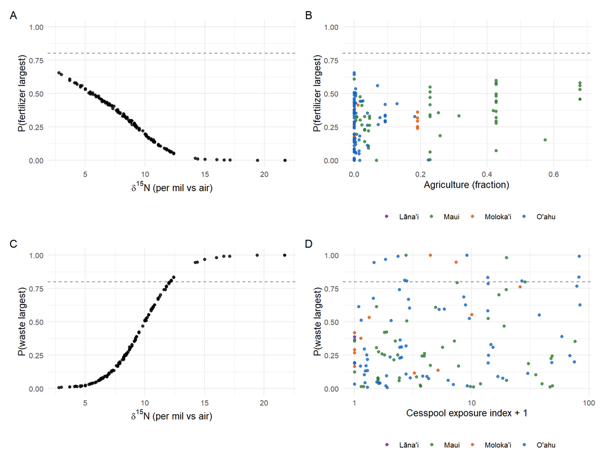

Figure 13: Probability that a sample’s nitrate is agriculture-derived (A, B) or waste-associated (C, D) in the isotope-only three-source model (no enrichment allowance; probability = P(source has the largest fraction)). A: fertilizer probability against d15N; B: against agricultural land cover. C: waste probability against d15N; D: against cesspool exposure index (log axis, 1 added). Points are posterior means; dashed line = 0.8, the confident-call threshold. Probabilities are a monotone function of d15N alone (A, C), so panels B and D restate the d15N-land-use relationships of the exploratory section.

```r
d0 <- filter(ag_iso, enrichment == "none")
pa <- ggplot(d0, aes(N15, p_fert_largest)) + geom_hline(yintercept = 0.8, linetype = "dashed", color = "gray50") +
  geom_point(alpha = 0.8) + ylim(0, 1) +
  labs(x = expression(delta^{15}*N~"(per mil vs air)"), y = "P(fertilizer largest)", tag = "A") + theme_minimal(base_size = 10)
pb <- ggplot(d0, aes(pct_agriculture, p_fert_largest, color = island)) + geom_hline(yintercept = 0.8, linetype = "dashed", color = "gray50") +
  geom_point(alpha = 0.8) + ylim(0, 1) + scale_color_manual(values = island_pal, name = NULL) +
  labs(x = "Agriculture (fraction)", y = "P(fertilizer largest)", tag = "B") + theme_minimal(base_size = 10) + theme(legend.position = "bottom")
pc <- ggplot(d0, aes(N15, p_waste_largest)) + geom_hline(yintercept = 0.8, linetype = "dashed", color = "gray50") +
  geom_point(alpha = 0.8) + ylim(0, 1) +
  labs(x = expression(delta^{15}*N~"(per mil vs air)"), y = "P(waste largest)", tag = "C") + theme_minimal(base_size = 10)
pd <- ggplot(d0, aes(cess_exposure_idx + 1, p_waste_largest, color = island)) + geom_hline(yintercept = 0.8, linetype = "dashed", color = "gray50") +
  geom_point(alpha = 0.8) + ylim(0, 1) + scale_x_log10() + scale_color_manual(values = island_pal, name = NULL) +
  labs(x = "Cesspool exposure index + 1", y = "P(waste largest)", tag = "D") + theme_minimal(base_size = 10) + theme(legend.position = "bottom")
(pa | pb) / (pc | pd)
```

## 6.2 Does land use predict the fractions? (joint model)

```r
ag_lu_terms <- c("z_log_cess_exposure", "z_pct_agriculture")
ag_joint |>
  filter(term %in% ag_lu_terms) |>
  select(enrichment, equation, term, beta_mean, beta_lwr, beta_upr, p_positive) |>
  knitr::kable(digits = 2, caption = "Joint model: effect on the log-ratio of waste (or fertilizer) to background nitrate per SD of the predictor (95% credible interval, P(beta > 0)).")
```

Joint model: effect on the log-ratio of waste (or fertilizer) to background nitrate per SD of the predictor (95% credible interval, P(beta > 0)).

| enrichment | equation | term | beta_mean | beta_lwr | beta_upr | p_positive |
| --- | --- | --- | --- | --- | --- | --- |
| none | waste_vs_bg | z_log_cess_exposure | 0.27 | -0.12 | 0.84 | 0.92 |
| none | waste_vs_bg | z_pct_agriculture | -0.25 | -0.62 | 0.19 | 0.09 |
| none | fert_vs_bg | z_log_cess_exposure | 0.15 | -1.47 | 1.50 | 0.59 |
| none | fert_vs_bg | z_pct_agriculture | -0.16 | -1.65 | 0.99 | 0.44 |
| moderate | waste_vs_bg | z_log_cess_exposure | 0.40 | -0.13 | 1.05 | 0.93 |
| moderate | waste_vs_bg | z_pct_agriculture | -0.41 | -1.18 | 0.33 | 0.12 |
| moderate | fert_vs_bg | z_log_cess_exposure | 0.07 | -1.41 | 1.45 | 0.55 |
| moderate | fert_vs_bg | z_pct_agriculture | 0.13 | -1.53 | 1.34 | 0.62 |

```r
ag_dfrac |>
  select(enrichment, term, source, dfrac_mean, dfrac_lwr, dfrac_upr) |>
  knitr::kable(digits = 3, caption = "Change in the mean source fraction per SD of the predictor (O'ahu, median random effects). W = waste, F = fertilizer.")
```

Change in the mean source fraction per SD of the predictor (O’ahu, median random effects). W = waste, F = fertilizer.

| enrichment | term | source | dfrac_mean | dfrac_lwr | dfrac_upr |
| --- | --- | --- | --- | --- | --- |
| none | z_log_cess_exposure | W | 0.052 | -0.010 | 0.121 |
| none | z_log_cess_exposure | F | 0.007 | -0.063 | 0.096 |
| none | z_pct_agriculture | W | -0.059 | -0.127 | 0.010 |
| none | z_pct_agriculture | F | 0.006 | -0.058 | 0.091 |
| moderate | z_log_cess_exposure | W | 0.060 | -0.011 | 0.157 |
| moderate | z_log_cess_exposure | F | 0.007 | -0.085 | 0.131 |
| moderate | z_pct_agriculture | W | -0.052 | -0.122 | 0.026 |
| moderate | z_pct_agriculture | F | 0.025 | -0.072 | 0.168 |

```r
ag_perm |>
  filter(term %in% ag_lu_terms) |>
  left_join(ag_joint |> filter(term %in% ag_lu_terms) |> select(enrichment, equation, term, obs_beta = beta_mean),
            by = c("enrichment", "equation", "term")) |>
  group_by(enrichment, equation, term) |>
  summarise(n_perm = n(), null_sd_of_posterior_means = sd(beta_mean), mean_posterior_sd = mean(beta_sd), obs_beta = first(obs_beta),
            share_null_abs_beta_ge_observed = mean(abs(beta_mean) >= abs(obs_beta)), .groups = "drop") |>
  knitr::kable(digits = 2, caption = "Permutation null: d15N shuffled across samples, covariates and sites unchanged. With 8 shuffles the null shares have a resolution of 0.125.")
```

Permutation null: d15N shuffled across samples, covariates and sites unchanged. With 8 shuffles the null shares have a resolution of 0.125.

| enrichment | equation | term | n_perm | null_sd_of_posterior_means | mean_posterior_sd | obs_beta | share_null_abs_beta_ge_observed |
| --- | --- | --- | --- | --- | --- | --- | --- |
| moderate | fert_vs_bg | z_log_cess_exposure | 8 | 0.33 | 0.70 | 0.07 | 0.88 |
| moderate | fert_vs_bg | z_pct_agriculture | 8 | 0.27 | 0.70 | 0.13 | 0.38 |
| moderate | waste_vs_bg | z_log_cess_exposure | 8 | 0.13 | 0.30 | 0.40 | 0.12 |
| moderate | waste_vs_bg | z_pct_agriculture | 8 | 0.18 | 0.31 | -0.41 | 0.00 |
| none | fert_vs_bg | z_log_cess_exposure | 8 | 0.26 | 0.69 | 0.15 | 0.38 |
| none | fert_vs_bg | z_pct_agriculture | 8 | 0.22 | 0.71 | -0.16 | 0.50 |
| none | waste_vs_bg | z_log_cess_exposure | 8 | 0.07 | 0.22 | 0.27 | 0.00 |
| none | waste_vs_bg | z_pct_agriculture | 8 | 0.10 | 0.23 | -0.25 | 0.00 |

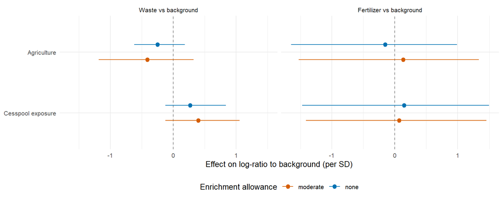

Figure 14: Joint three-source model: effects of cesspool exposure and agricultural land cover on the log-ratio of waste (A) and fertilizer (B) to background nitrate, per SD of the predictor, adjusted for the other predictor, island and ahupua’a (points = posterior mean, bars = 95% credible interval). Models without and with an enrichment allowance.

```r
ag_forest <- ag_joint |>
  filter(term %in% ag_lu_terms) |>
  mutate(term = factor(term, ag_lu_terms, labels = c("Cesspool exposure", "Agriculture")),
         panel = factor(equation, c("waste_vs_bg", "fert_vs_bg"), labels = c("Waste vs background", "Fertilizer vs background")))
ggplot(ag_forest, aes(beta_mean, term, color = enrichment, xmin = beta_lwr, xmax = beta_upr)) +
  geom_vline(xintercept = 0, linetype = "dashed", color = "gray50") +
  geom_pointrange(position = position_dodge(width = 0.5), size = 0.4) +
  facet_wrap(~panel) +
  scale_color_manual(values = c(none = "#0072B2", moderate = "#D55E00"), name = "Enrichment allowance") +
  labs(x = "Effect on log-ratio to background (per SD)", y = NULL) +
  theme_minimal(base_size = 10) + theme(legend.position = "bottom")
```

```r
ag_fe <- \(e, q, t) ag_joint[ag_joint$enrichment == e & ag_joint$equation == q & ag_joint$term == t, ]
ag_fmt <- \(r) sprintf("%.2f (%.2f to %.2f)", r$beta_mean, r$beta_lwr, r$beta_upr)
```

### 6.2.1 What the three-source model shows

- **No sample can be called agriculture-derived.** The largest P(fertilizer largest) in the isotope-only model is 0.66, and no sample reaches 0.8 under either enrichment setting. Fertilizer (0.3 per mil) and background (3.0 per mil) overlap too much, as the simulations predicted (agriculture vs background AUC about 0.6). By contrast 14 samples (no enrichment) and 9 (enrichment) reach 0.8 for waste.
- **P(fertilizer largest) is the mirror image of d15N** (rank correlation -1.00): the lowest-d15N samples get the highest value. It therefore carries no information beyond d15N rank, and a sample with low d15N is just as consistent with natural soil or marine nitrate.
- **Agriculture does not predict the fertilizer fraction.** In the joint model the agriculture effect on the fertilizer-to-background log-ratio is -0.16 (-1.65 to 0.99) with no enrichment allowance and 0.13 (-1.53 to 1.34) with it; the posterior SD (about 0.7) is close to the prior SD of 1 and the shuffled-d15N fits are about as variable as the data, so this term is essentially uninformed. The data neither support nor rule out a fertilizer contribution.
- **Agriculture is associated with a lower waste fraction, cesspool exposure with a higher one**, repeating the two-source result in a different parameterization: waste-vs-background effect of agriculture -0.25 (-0.62 to 0.19) and of cesspool exposure 0.27 (-0.12 to 0.84) (no enrichment). Both intervals include zero, and the shifts in the mean waste fraction are about 5 to 6 percentage points per SD. In the permutation null, none of the 8 shuffles per setting produced a waste-vs-background agriculture effect as large as observed, but 8 shuffles is a coarse check.
- **What this means for the paper’s question.** Isotopes support, weakly, the cesspool side (waste-like nitrate rises with cesspool exposure) and are structurally unable to test the agriculture side with the current source set. Lower d15N where agriculture is high is the pattern fertilizer nitrate would produce, but natural soil nitrate would produce it too. Testing the agricultural contribution would need a second tracer (nitrate d18O, or a pesticide or fertilizer-specific indicator), and animal-waste agriculture would still be indistinguishable from wastewater by d15N.
- **Caveat on the ‘probability’.** These are model-based probabilities conditional on the literature endmembers, on the pooled background source and on Dirichlet priors; they are not measured source attributions, and enrichment (denitrification-like shifts) would move samples toward the waste class.

## 6.3 Does separating manure change the agriculture result?

The three-source model treats manure as part of the waste source. Animal-waste agriculture could instead be what links agricultural land cover to nitrate, so this check adds manure (mean 12.5 per mil, SD 8.2) as a fourth source next to wastewater, synthetic fertilizer and background, with the same isotope-only design (Dirichlet(1, 1, 1, 1) fractions, no covariates). “Agriculture-derived” is reported as fertilizer alone and as fertilizer + manure. Land use is related to the fractions afterwards with the modular repeated-draw regression (300 draws, Rubin’s rules, ahupuaʻa-clustered SEs). Code: `scripts/isotope_09_four_source_manure.R` and `isotope_four_source_mixing.stan`.

```r
ag4_s <- read_csv(file.path(ag_dir, "ag4_sample_posteriors.csv"), show_col_types = FALSE)
ag4_pop <- read_csv(file.path(ag_dir, "ag4_population_fractions.csv"), show_col_types = FALSE)
ag4_mod <- read_csv(file.path(ag_dir, "ag4_modular_effects.csv"), show_col_types = FALSE)
read_csv(file.path(ag_dir, "ag4_diagnostics.csv"), show_col_types = FALSE) |>
  knitr::kable(digits = 2, caption = "Four-source model convergence (4 chains).")
```

Four-source model convergence (4 chains).

| enrichment | n_divergent | max_rhat | min_ess_bulk | min_ebfmi |
| --- | --- | --- | --- | --- |
| none | 0 | 1 | 1300.23 | 0.72 |
| moderate | 0 | 1 | 2252.60 | 0.72 |

```r
ag4_pop |> knitr::kable(digits = 2, caption = "Population-mean fractions (average over samples; 95% interval). A uniform Dirichlet prior alone gives 0.25 per source.")
```

Population-mean fractions (average over samples; 95% interval). A uniform Dirichlet prior alone gives 0.25 per source.

| enrichment | quantity | mean | lwr | upr |
| --- | --- | --- | --- | --- |
| none | waste | 0.25 | 0.22 | 0.29 |
| none | manure | 0.25 | 0.22 | 0.29 |
| none | fertilizer | 0.24 | 0.21 | 0.27 |
| none | background | 0.25 | 0.22 | 0.29 |
| none | fertilizer + manure | 0.49 | 0.46 | 0.53 |
| none | waste + manure | 0.51 | 0.47 | 0.54 |
| moderate | waste | 0.24 | 0.21 | 0.27 |
| moderate | manure | 0.24 | 0.21 | 0.28 |
| moderate | fertilizer | 0.26 | 0.22 | 0.29 |
| moderate | background | 0.26 | 0.23 | 0.29 |
| moderate | fertilizer + manure | 0.50 | 0.46 | 0.54 |
| moderate | waste + manure | 0.48 | 0.45 | 0.52 |

```r
ag4_s |>
  group_by(enrichment) |>
  summarise(max_P_fert_largest = max(p_fert_largest), max_P_manure_largest = max(p_manure_largest),
            n_any_source_P_ge_0.8 = sum(pmax(p_fert_largest, p_manure_largest, p_waste_largest, p_bg_largest) >= 0.8),
            max_P_fert_plus_manure_gt_0.5 = max(p_ag_total_gt50),
            rho_ag_total_vs_agriculture = cor(f_ag_total, pct_agriculture, method = "spearman"),
            rho_manure_vs_agriculture = cor(f_manure, pct_agriculture, method = "spearman"),
            rho_waste_plus_manure_vs_cesspool = cor(f_waste + f_manure, cess_exposure_idx, method = "spearman")) |>
  knitr::kable(digits = 2, caption = "Sample-level probabilities and unadjusted rank correlations (posterior-mean fractions).")
```

Sample-level probabilities and unadjusted rank correlations (posterior-mean fractions).

| enrichment | max_P_fert_largest | max_P_manure_largest | n_any_source_P_ge_0.8 | max_P_fert_plus_manure_gt_0.5 | rho_ag_total_vs_agriculture | rho_manure_vs_agriculture | rho_waste_plus_manure_vs_cesspool |
| --- | --- | --- | --- | --- | --- | --- | --- |
| moderate | 0.51 | 0.39 | 0 | 0.66 | 0.20 | -0.21 | 0.17 |
| none | 0.59 | 0.43 | 0 | 0.66 | 0.21 | -0.21 | 0.17 |

```r
ag4_mod |>
  knitr::kable(digits = 2, caption = "Modular regression of logit fractions on cesspool exposure and agriculture (per SD; island fixed; ahupuaʻa-clustered SEs).")
```

Modular regression of logit fractions on cesspool exposure and agriculture (per SD; island fixed; ahupuaʻa-clustered SEs).

| enrichment | response | term | estimate | se | lwr | upr | p_two_sided |
| --- | --- | --- | --- | --- | --- | --- | --- |
| none | fertilizer | z_log_cess_exposure | -0.10 | 0.17 | -0.43 | 0.22 | 0.54 |
| none | fertilizer | z_pct_agriculture | 0.12 | 0.16 | -0.20 | 0.45 | 0.45 |
| none | fertilizer + manure | z_log_cess_exposure | -0.02 | 0.14 | -0.29 | 0.26 | 0.91 |
| none | fertilizer + manure | z_pct_agriculture | 0.02 | 0.14 | -0.26 | 0.30 | 0.90 |
| none | manure | z_log_cess_exposure | 0.06 | 0.17 | -0.26 | 0.39 | 0.71 |
| none | manure | z_pct_agriculture | -0.12 | 0.17 | -0.45 | 0.22 | 0.49 |
| none | waste | z_log_cess_exposure | 0.09 | 0.17 | -0.24 | 0.42 | 0.59 |
| none | waste | z_pct_agriculture | -0.12 | 0.16 | -0.44 | 0.19 | 0.45 |
| none | waste + manure | z_log_cess_exposure | 0.12 | 0.12 | -0.10 | 0.35 | 0.28 |
| none | waste + manure | z_pct_agriculture | -0.17 | 0.11 | -0.39 | 0.06 | 0.14 |
| moderate | fertilizer | z_log_cess_exposure | -0.08 | 0.16 | -0.41 | 0.24 | 0.61 |
| moderate | fertilizer | z_pct_agriculture | 0.10 | 0.16 | -0.22 | 0.42 | 0.55 |
| moderate | fertilizer + manure | z_log_cess_exposure | -0.02 | 0.14 | -0.30 | 0.25 | 0.86 |
| moderate | fertilizer + manure | z_pct_agriculture | 0.02 | 0.14 | -0.25 | 0.30 | 0.87 |
| moderate | manure | z_log_cess_exposure | 0.05 | 0.18 | -0.31 | 0.40 | 0.80 |
| moderate | manure | z_pct_agriculture | -0.08 | 0.17 | -0.41 | 0.24 | 0.63 |
| moderate | waste | z_log_cess_exposure | 0.09 | 0.16 | -0.23 | 0.41 | 0.59 |
| moderate | waste | z_pct_agriculture | -0.10 | 0.17 | -0.42 | 0.23 | 0.56 |
| moderate | waste + manure | z_log_cess_exposure | 0.11 | 0.13 | -0.14 | 0.35 | 0.40 |
| moderate | waste + manure | z_pct_agriculture | -0.13 | 0.13 | -0.37 | 0.12 | 0.32 |

- **No sample can be assigned to fertilizer or manure.** The largest P(fertilizer largest) is 0.59 and the largest P(manure largest) is 0.43; no sample has any source above 0.8 under either enrichment setting. P(fertilizer + manure > 0.5) never exceeds 0.66.
- **The population fractions are the prior.** Each source’s mean fraction is about 0.24 to 0.26, with intervals of roughly 0.21 to 0.29, which is what the Dirichlet prior gives with no data. With four sources and one isotope the data cannot apportion nitrate; d15N mostly fixes the ordering of samples between low (fertilizer, background) and high (wastewater, manure) values.
- **Combining manure with fertilizer does not create an agriculture signal.** The fertilizer + manure fraction has a modular effect of agriculture of 0.02 (-0.26 to 0.30) on the logit scale (no enrichment), essentially zero because the two components move in opposite directions along d15N (manure rises, fertilizer falls with d15N). Fertilizer alone is +0.12 (-0.20 to 0.45) and manure alone -0.12 (-0.45 to 0.22), both centred near zero.
- **The waste-side result is unchanged.** Waste + manure falls with agriculture (-0.17, -0.39 to 0.06) and rises with cesspool exposure (+0.12, -0.10 to 0.35), the same directions as the two- and three-source models, again with intervals that include zero. Nothing here suggests that animal-waste agriculture explains a positive agriculture link; but the isotope data also cannot exclude it, because manure and wastewater overlap (about 0.8) and are not separable.
- **Reading.** Adding manure does not change the conclusion: d15N alone cannot test whether agriculture, fertilizer-derived or animal-waste-derived, raises nitrate. The identifiable contrast remains high-d15N (waste + manure) versus low-d15N (fertilizer + background) nitrate, and that contrast leans toward cesspools and away from agriculture.

# 7 Rainfall interactions

**Question.** The GAM found that NOx rises more steeply with storm rainfall where cesspool exposure and agricultural land cover are high. If rainfall delivered more waste-associated nitrate where exposure is high, the waste-associated fraction should increase with rainfall more steeply at high than at low exposure (a positive rainfall x exposure interaction). An enriched d15N during rain would not by itself prove more cesspool nitrogen, because transformation, dilution or residence time can also change d15N.

**Prespecified models** (code: `scripts/isotope_06_rainfall_interactions.R`). Each has storm rainfall, cesspool exposure, agriculture, island and an ahupuaʻa random intercept, plus the interaction terms: M4a adds rainfall x cesspool, M4b adds rainfall x agriculture, and M5 adds both together to check whether the two can be estimated jointly. Each is fitted two ways:

- as the **joint mixing + regression model** of Section 5 (response = waste-associated fraction, with and without the enrichment allowance); and
- with **observed d15N as the response** (brms Gaussian model, Normal(0, 2) priors on coefficients), which makes no mixing-model assumption.

Predictions use the ahupuaʻa-level z-scores at the 10th and 90th percentile of the isotope samples for the exposure of interest (the other exposure at its median, Oʻahu as the island), across rainfall from the 5th to the 95th percentile of the samples (about 139 to 650 mm). The joint-model curves show the population-average waste fraction (integrating over the sample-level and ahupuaʻa spread), with 95% credible bands.

```r
rn_int <- read_csv(file.path(mix_dir, "rain_joint_interactions.csv"), show_col_types = FALSE)
rn_pred <- read_csv(file.path(mix_dir, "rain_joint_predictions.csv"), show_col_types = FALSE)
rn_bint <- read_csv(file.path(mix_dir, "rain_brms_interactions.csv"), show_col_types = FALSE)
rn_bpred <- read_csv(file.path(mix_dir, "rain_brms_predictions.csv"), show_col_types = FALSE)
rn_lev <- read_csv(file.path(mix_dir, "rain_exposure_levels.csv"), show_col_types = FALSE)
rn_cover <- read_csv(file.path(mix_dir, "rain_design_coverage.csv"), show_col_types = FALSE)

# observed rainfall range of samples within 0.5 SD of each exposure level (beyond it the curves are extrapolation)
rn_range <- pmap_dfr(list(rn_lev$exposure, rn_lev$z_lo, rn_lev$z_hi), \(ex, lo, hi) {
  col <- if (ex == "cesspool") "z_log_cess_exposure" else "z_pct_agriculture"
  map_dfr(c(low = lo, high = hi), \(z) {
    s <- water_iso[abs(water_iso[[col]] - z) <= 0.5, ]
    tibble(n_samples = nrow(s), rain_min = min(s$chirps_storm_cumulative_mm), rain_max = max(s$chirps_storm_cumulative_mm),
           n_above_450mm = sum(s$chirps_storm_cumulative_mm > 450))
  }, .id = "level") |> mutate(exposure = ex, .before = 1)
})

rn_cover |> knitr::kable(caption = "Samples by exposure group (lowest quartile, middle, highest quartile) and storm rainfall band: where the data can inform an interaction.")
```

Samples by exposure group (lowest quartile, middle, highest quartile) and storm rainfall band: where the data can inform an interaction.

| exposure | group | <200 mm | 200-300 | 300-450 | >450 mm |
| --- | --- | --- | --- | --- | --- |
| agriculture | high | 12 | 22 | 2 | 0 |
| agriculture | low | 3 | 30 | 2 | 4 |
| agriculture | middle | 20 | 17 | 16 | 10 |
| cesspool | high | 15 | 7 | 8 | 6 |
| cesspool | low | 5 | 28 | 2 | 0 |
| cesspool | middle | 15 | 34 | 10 | 8 |

```r
rn_range |> knitr::kable(digits = 0, caption = "Samples within 0.5 SD of the low (10th percentile) and high (90th percentile) exposure levels, and the rainfall range they cover.")
```

Samples within 0.5 SD of the low (10th percentile) and high (90th percentile) exposure levels, and the rainfall range they cover.

| exposure | level | n_samples | rain_min | rain_max | n_above_450mm |
| --- | --- | --- | --- | --- | --- |
| cesspool | low | 51 | 129 | 367 | 0 |
| cesspool | high | 20 | 139 | 696 | 2 |
| agriculture | low | 93 | 129 | 948 | 14 |
| agriculture | high | 13 | 140 | 294 | 0 |

```r
bind_rows(
  rn_int |> transmute(response = "waste fraction (joint model, logit scale)", model, enrichment, term, estimate = beta_int_mean, sd = beta_int_sd, lwr = beta_int_lwr, upr = beta_int_upr, p_positive),
  rn_bint |> transmute(response = "observed d15N (per mil per SD x SD)", model, enrichment = "not applicable",
                       term = if_else(str_detect(term, "cess"), "rain_x_cess", "rain_x_ag"), estimate = mean, sd, lwr, upr, p_positive)) |>
  knitr::kable(digits = 2, caption = "Interaction coefficients per SD of rainfall x SD of exposure. Positive = rainfall slope steeper at higher exposure.")
```

Interaction coefficients per SD of rainfall x SD of exposure. Positive = rainfall slope steeper at higher exposure.

| response | model | enrichment | term | estimate | sd | lwr | upr | p_positive |
| --- | --- | --- | --- | --- | --- | --- | --- | --- |
| waste fraction (joint model, logit scale) | M4a_rain_x_cess | none | rain_x_cess | 0.13 | 0.24 | -0.30 | 0.64 | 0.71 |
| waste fraction (joint model, logit scale) | M4a_rain_x_cess | moderate | rain_x_cess | 0.08 | 0.29 | -0.49 | 0.65 | 0.61 |
| waste fraction (joint model, logit scale) | M4b_rain_x_ag | none | rain_x_ag | 0.01 | 0.31 | -0.57 | 0.67 | 0.50 |
| waste fraction (joint model, logit scale) | M4b_rain_x_ag | moderate | rain_x_ag | 0.12 | 0.52 | -0.91 | 1.19 | 0.58 |
| waste fraction (joint model, logit scale) | M5_both | none | rain_x_cess | 0.14 | 0.24 | -0.30 | 0.64 | 0.74 |
| waste fraction (joint model, logit scale) | M5_both | none | rain_x_ag | 0.01 | 0.32 | -0.61 | 0.69 | 0.49 |
| waste fraction (joint model, logit scale) | M5_both | moderate | rain_x_cess | 0.06 | 0.30 | -0.55 | 0.67 | 0.58 |
| waste fraction (joint model, logit scale) | M5_both | moderate | rain_x_ag | 0.10 | 0.55 | -0.95 | 1.18 | 0.57 |
| observed d15N (per mil per SD x SD) | M4a_rain_x_cess | not applicable | rain_x_cess | 0.40 | 0.58 | -0.72 | 1.55 | 0.76 |
| observed d15N (per mil per SD x SD) | M4b_rain_x_ag | not applicable | rain_x_ag | 0.15 | 0.85 | -1.49 | 1.90 | 0.56 |
| observed d15N (per mil per SD x SD) | M5_both | not applicable | rain_x_cess | 0.41 | 0.60 | -0.75 | 1.64 | 0.76 |
| observed d15N (per mil per SD x SD) | M5_both | not applicable | rain_x_ag | 0.13 | 0.87 | -1.55 | 1.87 | 0.55 |

```r
rn_int |>
  select(model, enrichment, exposure, contrast_mean, contrast_lwr, contrast_upr, n_divergent, max_rhat, min_ess_bulk, min_ebfmi) |>
  knitr::kable(digits = 2, caption = paste0("Difference in the rainfall slope (logit scale, per SD of rainfall) between the 90th and 10th percentile of exposure, and convergence ",
    "(brms models: at most 2 divergent transitions in 10,000 draws, Rhat at most 1.00)."))
```

Difference in the rainfall slope (logit scale, per SD of rainfall) between the 90th and 10th percentile of exposure, and convergence (brms models: at most 2 divergent transitions in 10,000 draws, Rhat at most 1.00).

| model | enrichment | exposure | contrast_mean | contrast_lwr | contrast_upr | n_divergent | max_rhat | min_ess_bulk | min_ebfmi |
| --- | --- | --- | --- | --- | --- | --- | --- | --- | --- |
| M4a_rain_x_cess | none | cesspool | 0.33 | -0.77 | 1.63 | 0 | 1.01 | 610.63 | 0.60 |
| M4a_rain_x_cess | moderate | cesspool | 0.20 | -1.24 | 1.66 | 0 | 1.00 | 882.31 | 0.67 |
| M4b_rain_x_ag | none | agriculture | 0.04 | -1.60 | 1.86 | 0 | 1.00 | 725.20 | 0.58 |
| M4b_rain_x_ag | moderate | agriculture | 0.32 | -2.53 | 3.30 | 0 | 1.00 | 928.46 | 0.68 |
| M5_both | none | cesspool | 0.35 | -0.76 | 1.63 | 0 | 1.01 | 788.52 | 0.57 |
| M5_both | none | agriculture | 0.02 | -1.70 | 1.92 | 0 | 1.01 | 788.52 | 0.57 |
| M5_both | moderate | cesspool | 0.14 | -1.40 | 1.70 | 0 | 1.00 | 942.04 | 0.71 |
| M5_both | moderate | agriculture | 0.28 | -2.64 | 3.30 | 0 | 1.00 | 942.04 | 0.71 |

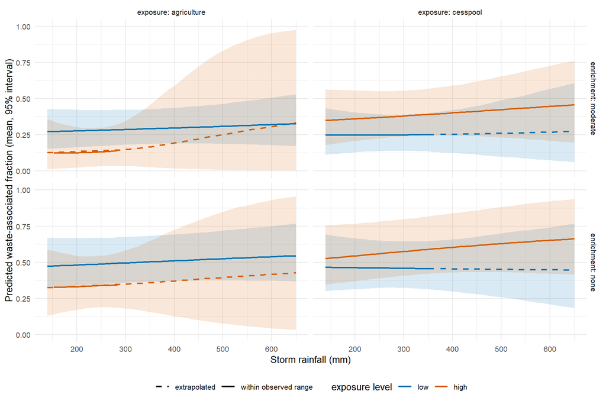

Figure 15

```r
pf <- rn_pred |>
  filter((model == "M4a_rain_x_cess" & exposure == "cesspool") | (model == "M4b_rain_x_ag" & exposure == "agriculture")) |>
  left_join(rn_range, by = c("exposure", "level")) |>
  mutate(in_range = rain_mm >= rain_min & rain_mm <= rain_max, level = factor(level, c("low", "high")),
         grp = interaction(level, in_range))

ggplot(pf, aes(rain_mm, fraction, color = level, fill = level)) +
  geom_ribbon(aes(ymin = lwr, ymax = upr, group = level), alpha = 0.15, color = NA) +
  geom_line(aes(group = grp, linetype = in_range), linewidth = 0.8) +
  scale_linetype_manual(values = c(`TRUE` = "solid", `FALSE` = "dashed"), labels = c(`TRUE` = "within observed range", `FALSE` = "extrapolated"), name = NULL) +
  scale_color_manual(values = c(low = "#0072B2", high = "#D55E00"), name = "exposure level") +
  scale_fill_manual(values = c(low = "#0072B2", high = "#D55E00"), guide = "none") +
  coord_cartesian(ylim = c(0, 1)) +
  facet_grid(enrichment ~ exposure, labeller = label_both) +
  labs(x = "Storm rainfall (mm)", y = "Predicted waste-associated fraction (mean, 95% interval)") +
  theme_minimal(base_size = 10) + theme(legend.position = "bottom")
```

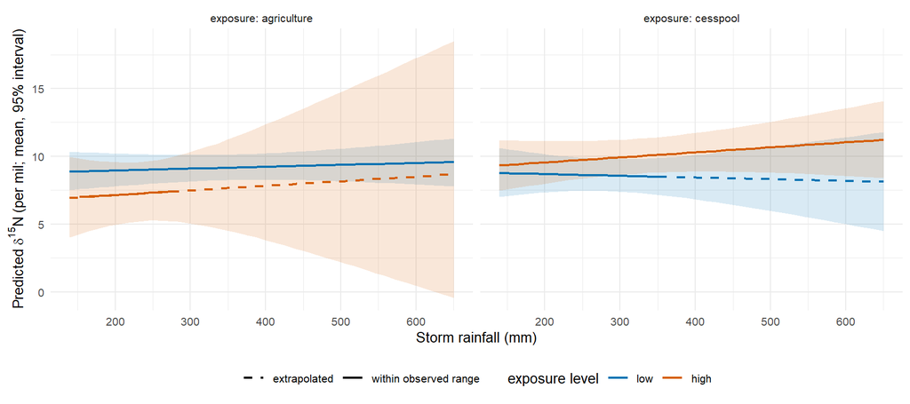

Figure 16

```r
pb <- rn_bpred |>
  filter((model == "M4a_rain_x_cess" & exposure == "cesspool") | (model == "M4b_rain_x_ag" & exposure == "agriculture")) |>
  left_join(rn_range, by = c("exposure", "level")) |>
  mutate(in_range = rain_mm >= rain_min & rain_mm <= rain_max, level = factor(level, c("low", "high")), grp = interaction(level, in_range))

ggplot(pb, aes(rain_mm, d15N, color = level, fill = level)) +
  geom_ribbon(aes(ymin = lwr, ymax = upr, group = level), alpha = 0.15, color = NA) +
  geom_line(aes(group = grp, linetype = in_range), linewidth = 0.8) +
  scale_linetype_manual(values = c(`TRUE` = "solid", `FALSE` = "dashed"), labels = c(`TRUE` = "within observed range", `FALSE` = "extrapolated"), name = NULL) +
  scale_color_manual(values = c(low = "#0072B2", high = "#D55E00"), name = "exposure level") +
  scale_fill_manual(values = c(low = "#0072B2", high = "#D55E00"), guide = "none") +
  facet_wrap(~exposure, labeller = label_both) +
  labs(x = "Storm rainfall (mm)", y = expression(Predicted~delta^{15}*N~"(per mil; mean, 95% interval)")) +
  theme_minimal(base_size = 10) + theme(legend.position = "bottom")
```

### 7.0.1 What the rainfall tests show

- **Neither interaction is distinguishable from zero, in either response.** Rainfall x cesspool is +0.13 (95% interval -0.30 to 0.64) on the logit scale with no enrichment allowance and +0.08 (-0.49 to 0.65) with it; for observed d15N it is +0.40 (-0.72 to 1.55) per mil. Rainfall x agriculture is +0.01 (-0.57 to 0.67) and +0.12 (-0.91 to 1.19), and +0.15 (-1.49 to 1.90) per mil. P(interaction > 0) is 0.50 to 0.76 throughout.
- **The data cannot rule out sizeable effects.** Between the 90th and 10th percentile of cesspool exposure the rainfall slope could differ by up to about +1.6 logit units per SD of rainfall (upper 95% bound), and by up to about +1.9 (no allowance) to +3.3 (with allowance) for agriculture. Posterior SDs of the interactions (0.24 to 0.52 logit units; 0.58 to 0.87 per mil) are too large to detect anything much smaller than that, so a null result here is weak evidence of no effect.
- **Both interactions can be fitted together, but add little.** M5 gives almost the same interaction estimates as the separate models (cesspool +0.14, agriculture +0.01 with no allowance) with slightly wider intervals (SD 0.24 and 0.33).
- **Predicted curves overlap.** At high cesspool exposure the predicted waste fraction goes from about 0.53 to 0.66 across the rainfall range, and at low exposure it stays at about 0.45 to 0.46; the bands (about 0.4 wide) overlap throughout. With no enrichment allowance the high-agriculture fraction is lower than the low-agriculture fraction at every rainfall (about 0.33 to 0.43 vs 0.47 to 0.55) with similar slopes, repeating the negative agriculture association from the previous section; with the allowance the high-agriculture curve rises (about 0.12 to 0.33) but its band is wide and overlaps the low-agriculture band.
- **Much of the plot is extrapolation.** There are no samples above 450 mm among the lowest-cesspool quartile, and the highest-agriculture samples (13 within 0.5 SD of the 90th percentile) cover only 140 to 294 mm. Beyond those ranges the curves are dashed. Because rainfall comes from 5 km CHIRPS pixels, many samples share a value, and the largest rainfall values rest on few pixels.
- **Mechanistic reading.** The isotopes neither show that rainfall delivers more waste-like nitrate where cesspool density is high nor argue against it. The GAM interaction (higher NOx at high exposure in storm-affected areas) could still arise from more delivery of waste-associated or fertilizer-like nitrate, with no change in the waste fraction if the added nitrate has a d15N similar to the background. An enriched signal during rainfall would not have proved cesspool loading, and the absence of one does not exclude it. Direct evidence would need a second tracer (for example nitrate d18O, or a wastewater indicator such as the optical brighteners already measured).

# 8 Figures: what the isotopes say about the drivers of nitrate

Figures are produced by `scripts/isotope_07_figures.R` from the saved model outputs and written to `output/isotope/figures/` as vector PDF and 600-dpi PNG. Panel letters are used, titles are left to the captions, and the island colours match the rest of the project.

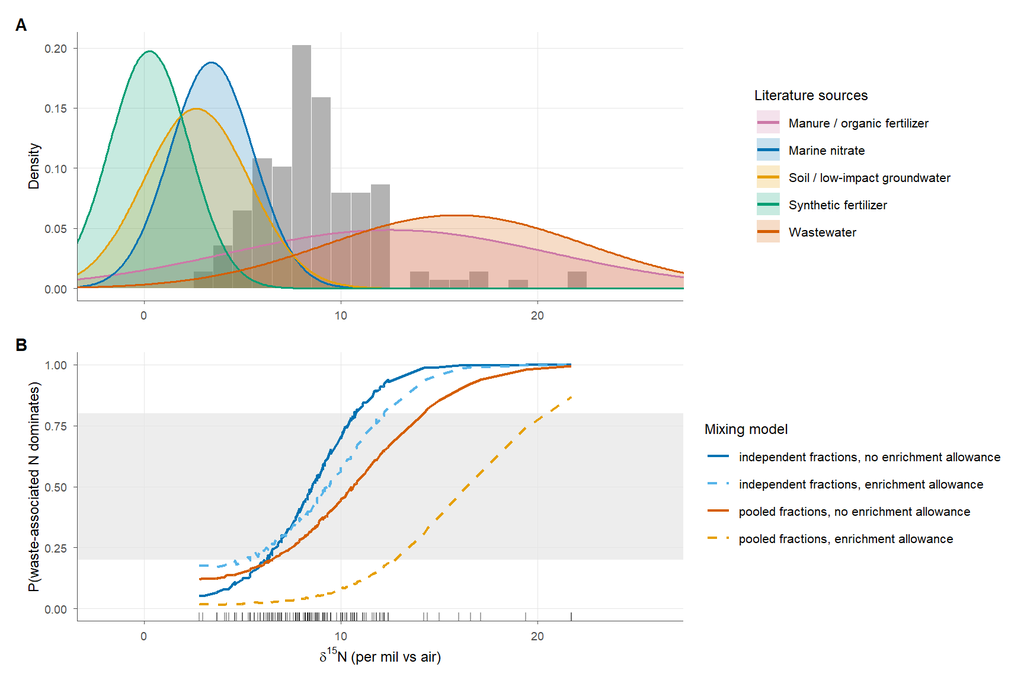

Figure 17: Observed d15N of nitrate (grey histogram) against the literature distributions of nitrogen sources (A), and the probability that waste-associated nitrogen dominates a sample as a function of d15N (B). Lines in B are the four mixing models; the grey band marks probabilities between 0.2 and 0.8, where a sample cannot be classified confidently; ticks mark the 138 samples. The independent models give each sample its own fraction; the pooled models share a population distribution of fractions; the enrichment allowance adds a denitrification-like shift of Uniform(0, 5) per mil.

```r
fig1
```

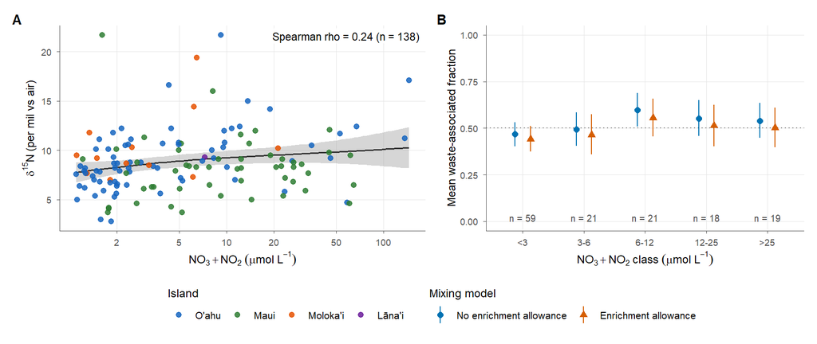

Figure 18: Nitrate concentration and d15N. (A) d15N against NO3+NO2 for the 138 isotope samples (line: GAM smooth with 95% band). (B) Mean waste-associated fraction by NO3+NO2 class (points and 95% credible intervals from the isotope-only independent mixing model, carrying posterior uncertainty; dotted line: 0.5; n = samples per class). Intervals cover isotope uncertainty only, not sampling variation among samples.

```r
fig2
```

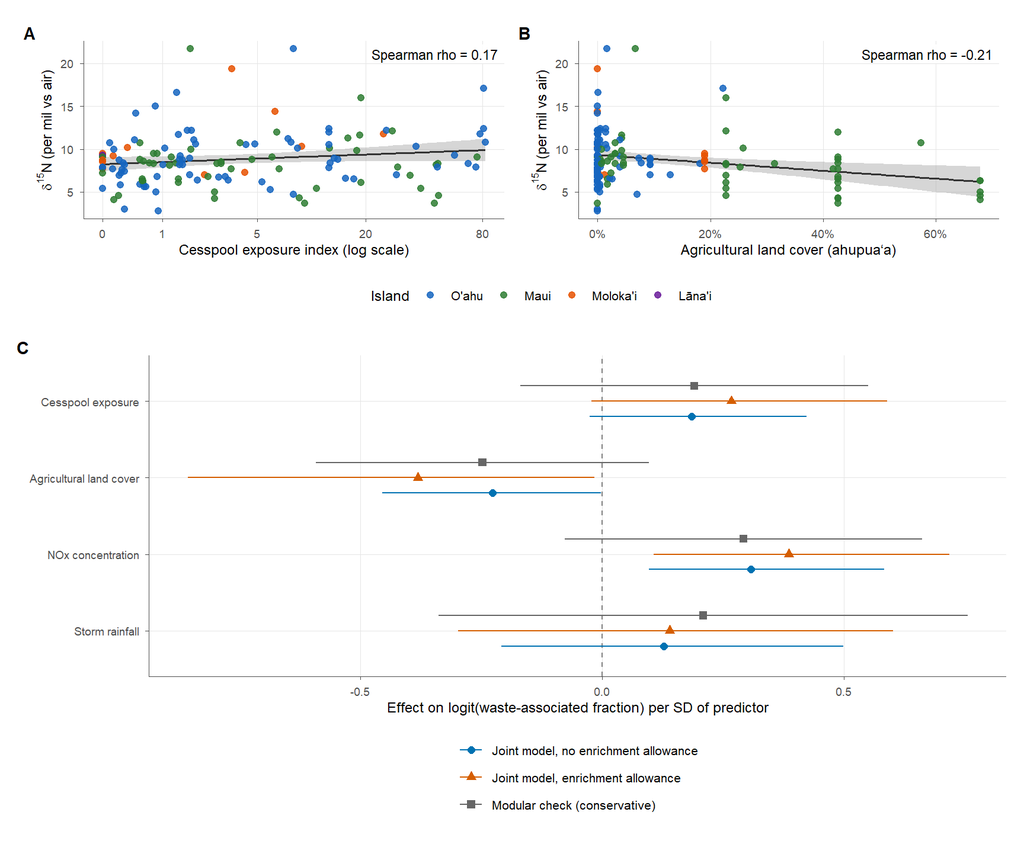

Figure 19: Land-use drivers. d15N against cesspool exposure (A) and agricultural land cover (B), with linear fits and 95% bands (unadjusted; Spearman correlations shown). (C) Effects on the logit of the waste-associated fraction per SD of each predictor, adjusted for the other predictors, island and ahupua’a: joint mixing-regression models without and with an enrichment allowance, and the conservative modular check (95% intervals).

```r
fig3
```

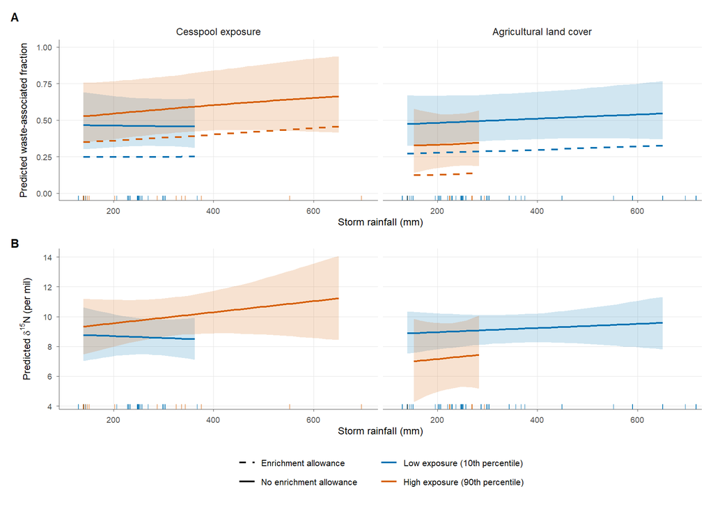

Figure 20: Rainfall interactions. Predicted waste-associated fraction (A; joint model, solid with 95% band = no enrichment allowance, dashed = enrichment allowance) and predicted d15N (B; observed-d15N model, 95% band) against storm rainfall at low (10th percentile) and high (90th percentile) cesspool exposure and agricultural land cover. Curves are shown only over the rainfall range of samples near each exposure level (rug marks).

```r
fig4
```

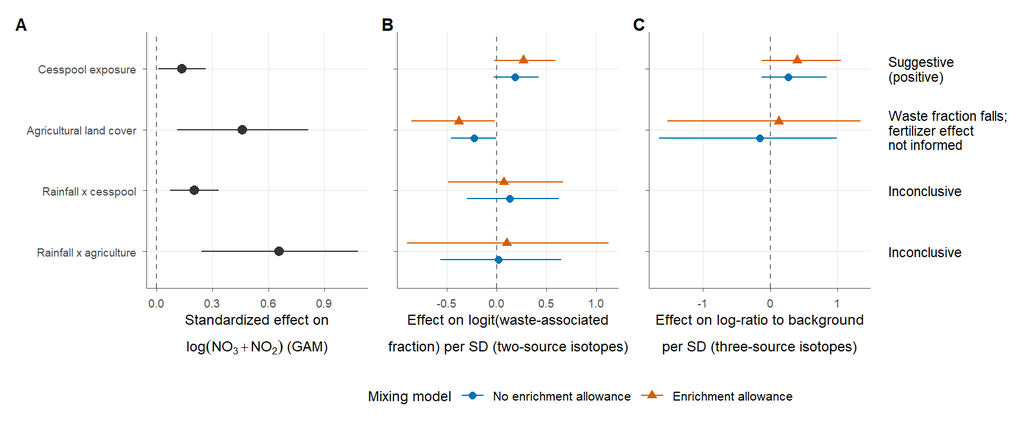

Figure 21: Drivers of NOx in the GAM (A; standardized effects on log NOx, 95% intervals) and the isotope-based tests of the same drivers: two-source model (B; effects on the logit of the waste-associated fraction per SD of the predictor, joint model) and three-source model (C; effects on the log-ratio of waste to background for cesspool exposure and of fertilizer to background for agricultural land cover, joint model; no estimates for the rainfall interactions). Text gives the reading of each driver.

```r
fig5
```

**What the figures show.**

- **The isotopes place most samples between the sources (Figure 1).** Median d15N is 8.4 per mil, above the fertilizer, soil and marine distributions and below the centre of the wastewater distribution. P(waste-associated N dominates) is a smooth function of d15N, and where it crosses 0.5 shifts from about 8.5 per mil to about 16 per mil depending on the model, so d15N alone cannot classify most samples.
- **Nitrate concentration is not clearly tied to a source (Figure 2).** d15N is weakly related to NOx (Spearman rho = 0.24) and the mean waste fraction is about 0.44 to 0.6 in every concentration class with overlapping intervals.
- **The clearest isotope-visible land-use signals are agricultural lightening and a modest cesspool enrichment (Figure 3).** d15N is lower where agricultural land cover is high (rho = -0.21) and slightly higher with cesspool exposure (rho = 0.17). After adjustment the cesspool effect on the waste fraction is positive but touches zero, and the agriculture effect is negative.
- **There is no detectable rainfall amplification in the isotopes (Figure 4).** Predicted curves at low and high exposure have overlapping bands over the range the data cover, so rainfall x exposure effects are not resolved.
- **Taken together (Figure 5),** the isotopes lean toward the GAM’s cesspool effect on NOx but cannot confirm it. Agriculture lowers the waste fraction, but the three-source model (panel C) finds no information on a fertilizer contribution (the fertilizer-vs-background effect is centred near zero with a very wide interval), so the agricultural and interaction effects are not tested and nothing contradicts the GAM. Direct support for either source would need a second tracer.

# 9 Background

# 10 Methods

## 10.1 Isotope laboratory methods (from the lab’s description; to be completed)

Water samples were filtered and frozen before analysis (user-reported). The lab’s method note says the analysis used a ThermoFinnigan instrument (the text is cut off in the screenshot provided, so the exact model and the nitrate conversion method are not recorded yet). Isotopic corrections used standards prepared by the lab and run alongside the samples: IAEA-N3, USGS32, USGS34, USGS35, and an off-the-shelf NaNO3 with a d15N of -52.2 per mil.

Still needed for this section: the nitrate conversion method (for example bacterial denitrifier), the analyzer model, the reported precision (SD of replicate standards or samples, which sets the analytical error term in the mixing model), the minimum nitrate mass or concentration for reliable d15N, and whether the measured pool is NO3 only or NO3 + NO2 (the user reports it as NOx).

## 10.2 Isotope mixing models (draft)

**Samples and covariates.** Analyses used the 138 samples with a valid d15N (56 ahupuaʻa). Because isotope samples were targeted at NOx of at least about 1.1 umol/L (Section 2.1), results apply to nitrate-enriched water only. Cesspool exposure (log of one plus the exposure index), agricultural land cover and storm rainfall were standardized with the means and SDs of the NOx GAM data, so coefficients share the GAM’s scale. Island was a fixed effect (Oʻahu as reference) and ahupuaʻa a random intercept; cesspool and agriculture are ahupuaʻa-level values.

| Source | Mean (per mil) | Source SD | SE of mean | Used in |
| --- | --- | --- | --- | --- |
| Wastewater | 15.9 | 6.5 | 1.7 | all models |
| Manure | 12.5 | 8.2 | 2.0 | four-source |
| Synthetic fertilizer | 0.3 | 2.0 | 0.7 | three- and four-source |
| Background (soil + marine) | 3.0 | 2.5 | 0.6 | three- and four-source |
| Other (fertilizer + soil + marine pooled) | 2.1 | 2.8 | 0.5 | two-source |

Manure is excluded from the two- and three-source models because it overlaps wastewater (overlap about 0.8); animal-waste agriculture then loads on the waste source. The four-source model tests that choice. Hawaiʻi-specific cesspool nitrate values are scarce (three Puako samples), so the wastewater prior leans on treated effluent and general septic values; the identifiability study (Section 3) used a cesspool-like N(11, 4.5) source as a sensitivity case.

**Likelihood and enrichment allowance.** For sample i with source fractions f,
$$y_i \sim \mathrm{Normal}\big(\textstyle\sum_k f_{ik}\mu_k + e,\ \sqrt{\textstyle\sum_k f_{ik}^2 s_k^2 + \sigma_a^2 + \tau_e^2}\big)$$
with analytical SD
$$\sigma_a = 0.3$$
per mil (fixed; a placeholder until the laboratory reports its precision, and shown to matter little). Denitrification-like enrichment shifts nitrate toward heavier d15N and, if ignored, inflates the waste fraction. Every model is therefore fitted twice: with no allowance (
$$e = 0, \tau_e = 0$$
) and with a moderate allowance (
$$e = 2.5, \tau_e = 1.44$$
per mil, equivalent to a Uniform(0, 5) shift). Results are reported under both, and conclusions are judged by whether they survive both.

**Fractions.** The two-source model (waste vs other) was fitted with independent uniform fractions per sample and with pooled fractions (Beta distribution with population mean
$$\pi_W$$
and concentration
$$\kappa$$
). Pooled and independent versions were compared by leave-one-out prediction with the fractions integrated out. Sample-level results are reported as P(a source has the largest fraction) or P(f > 0.5), not as point fractions, because simulations showed per-sample fractions are weakly identified (Section 3.4). The three-source (waste, fertilizer, background) and four-source (adding manure) models use uniform Dirichlet fractions per sample and no covariates.

**Land-use tests.** Two analyses carry isotope uncertainty into the land-use effects. (i) *Joint models*: the mixing model is fitted together with a regression of the fraction on standardized predictors, island, an ahupuaʻa random intercept and a sample-level residual, with Normal(0, 1) priors on coefficients. In the two-source version the logit of the waste fraction is the response; in the three-source version a multinomial-logit has background as the reference, so waste-vs-background and fertilizer-vs-background log-ratios each have their own coefficients. (ii) *Modular repeated-draw analysis*: 300 posterior draws of the fractions from the covariate-free model are each regressed on the predictors (logit scale, draws clipped to 0.001 to 0.999, island fixed, ahupuaʻa-clustered HC1 standard errors) and pooled with Rubin’s rules. Because the draws ignore the covariates, this check is expected to be attenuated and is treated as conservative. The same modular analysis was applied to the four-source fractions, including the combined fertilizer + manure fraction. Prespecified two-source models were cesspool + agriculture, plus NOx, plus rainfall, and the rainfall x cesspool and rainfall x agriculture interactions (fitted separately, and together as a check). Observed d15N was also modelled directly (brms, Gaussian, Normal(0, 2) priors) as a mixing-model-free check on the interactions. As a null reference, d15N was shuffled across samples with covariates and sites unchanged (10 shuffles per enrichment setting for the two-source joint model, 8 for the three-source), which is a coarse check.

**Fitting and diagnostics.** Models were fitted in Stan through rstan (four chains; 2,000 to 3,000 iterations for the independent and covariate models, 6,000 for the pooled model, adapt_delta 0.95 to 0.99). We report divergences, Rhat, bulk ESS and E-BFMI, and posterior predictive checks of the mean and SD of d15N. The pooled two-source model has low E-BFMI, so its population parameters are read cautiously. A single seed (2847) is set per script. Code is in `scripts/isotope_04` to `isotope_09`.

# 11 Results

# 12 Discussion

**What the isotopes can and cannot say about cesspools versus agriculture.** Across the two-, three- and four-source models the isotopes lean toward a cesspool contribution and are unable to test an agricultural one. Waste-associated nitrate rises with cesspool exposure in every parameterization (two-source joint model +0.18, 95% interval -0.03 to 0.42, on the logit scale per SD, with larger effects when enrichment is allowed), but no interval excludes zero in the conservative checks, so the evidence is suggestive, not established. Agricultural land cover goes with lighter d15N and a lower waste fraction, which is what fertilizer or natural soil nitrate would produce, but fertilizer, soil and marine nitrate overlap so heavily that the three-source model finds no information on a fertilizer contribution (effect on the fertilizer-vs-background log-ratio centred near zero with a very wide interval), and no sample can be called agriculture-derived with confidence. Adding manure does not rescue the test: manure and wastewater are not separable, the fertilizer + manure fraction shows no relationship with agriculture, and the four-source population fractions stay near their prior. The isotopes therefore neither confirm nor contradict the GAM’s agricultural effect on NOx, and they show no rainfall amplification for either source, with intervals wide enough to include effects of the GAM’s size. Because isotope samples were targeted at high NOx, and because the conclusions rest on literature endmembers and an assumed enrichment, the supportable statement is that nitrate-enriched water is more waste-like where cesspool exposure is higher; attributing nitrate to agriculture would need a second tracer such as nitrate d18O.